# Cancer

# 1 Description of DataSchema variable

The description of harmonised variable is the following:

- Short name: `cancer`
- Variable label: `Any malignancy (C00-D48) / information about past or current neoplasm (benign, in situ, malignant)`
- Variable description: `Cancer diagnosis since the last interview`
- Domain: `Diseases`
- Value type: `categorical`
- Category coding:

| **Code** | **Category Label** |
| --- | --- |
| 0 | no cancer |
| 1 | cancer |

- Category missings:

| **Code** | **Category Label** |
| --- | --- |
| 991 | CAPI/interviewer error |
| 992 | Impute |
| 993 | Disable to measure |
| 994 | Not attempt/not done |
| 995 | Does not answer |
| 996 | Not applicable |
| 997 | Refuse |
| 998 | Do not know |
| 999 | Missing |

- Short name: `cancer_age`
- Variable label: `Age of the last cancer diagnosis`
- Variable description: `Age of each episode of cancer`
- Domain: `Diseases`
- Value type: `Continuous`
- Category missings:

| **Code** | **Category Label** |
| --- | --- |
| 991 | CAPI/interviewer error |
| 992 | Impute |
| 993 | Disable to measure |
| 994 | Not attempt/not done |
| 995 | Does not answer |
| 996 | Not applicable |
| 997 | Refuse |
| 998 | Do not know |
| 999 | Missing |

# 2 Data process

## 2.1 England

### 2.1.1 Wave 1

#### 2.1.1.1 Study-specific variable description

| **Name** | `hedib01` | `hedib02` | `hedib03` | `hedib04` | `hedib05` | `hedib06` | `hedib07` | `hedib08` | `hedib09` | `hedib10` | `heagg` |
| --- | --- | --- | --- | --- | --- | --- | --- | --- | --- | --- | --- |
| **Label** | `Has a doctor ever told you that you [have/have had] any of the conditions in this card?{chronic lung disease ..}` | `Has a doctor ever told you that you [have/have had] any of the conditions in this card?{chronic lung disease ..}` | `Has a doctor ever told you that you [have/have had] any of the conditions in this card?{chronic lung disease ..}` | `Has a doctor ever told you that you [have/have had] any of the conditions in this card?{chronic lung disease ..}` | `Has a doctor ever told you that you [have/have had] any of the conditions in this card?{chronic lung disease ..}` | `Has a doctor ever told you that you [have/have had] any of the conditions in this card?{chronic lung disease ..}` | `Has a doctor ever told you that you [have/have had] any of the conditions in this card?{chronic lung disease ..}` | `Has a doctor ever told you that you [have/have had] any of the conditions in this card?{chronic lung disease ..}` | `Has a doctor ever told you that you [have/have had] any of the conditions in this card?{chronic lung disease ..}` | `Has a doctor ever told you that you [have/have had] any of the conditions in this card?{chronic lung disease ..}` | `Approximately how old were you when first told by a doctor that you had cancer or a malignant tumour? {years}` |
| **Table name** | `wave_1_core_data_v3` | `wave_1_core_data_v3` | `wave_1_core_data_v3` | `wave_1_core_data_v3` | `wave_1_core_data_v3` | `wave_1_core_data_v3` | `wave_1_core_data_v3` | `wave_1_core_data_v3` | `wave_1_core_data_v3` | `wave_1_core_data_v3` | `wave_1_core_data_v3` |
| **Categories** | `1 = Chronic lung disease such as chronic bronchitis or emphysema` `2 = Asthma` `3 = Arthritis (including osteoarthritis , or rheumatism)` `4 = Osteoporosis, sometimes called thin or brittle bones` `5… | `1 = Chronic lung disease such as chronic bronchitis or emphysema` `2 = Asthma` `3 = Arthritis (including osteoarthritis , or rheumatism)` `4 = Osteoporosis, sometimes called thin or brittle bones` `5… | `1 = Chronic lung disease such as chronic bronchitis or emphysema` `2 = Asthma` `3 = Arthritis (including osteoarthritis , or rheumatism)` `4 = Osteoporosis, sometimes called thin or brittle bones` `5… | `1 = Chronic lung disease such as chronic bronchitis or emphysema` `2 = Asthma` `3 = Arthritis (including osteoarthritis , or rheumatism)` `4 = Osteoporosis, sometimes called thin or brittle bones` `5… | `1 = Chronic lung disease such as chronic bronchitis or emphysema` `2 = Asthma` `3 = Arthritis (including osteoarthritis , or rheumatism)` `4 = Osteoporosis, sometimes called thin or brittle bones` `5… | `1 = Chronic lung disease such as chronic bronchitis or emphysema` `2 = Asthma` `3 = Arthritis (including osteoarthritis , or rheumatism)` `4 = Osteoporosis, sometimes called thin or brittle bones` `5… | `1 = Chronic lung disease such as chronic bronchitis or emphysema` `2 = Asthma` `3 = Arthritis (including osteoarthritis , or rheumatism)` `4 = Osteoporosis, sometimes called thin or brittle bones` `5… | `1 = Chronic lung disease such as chronic bronchitis or emphysema` `2 = Asthma` `3 = Arthritis (including osteoarthritis , or rheumatism)` `4 = Osteoporosis, sometimes called thin or brittle bones` `5… | `1 = Chronic lung disease such as chronic bronchitis or emphysema` `2 = Asthma` `3 = Arthritis (including osteoarthritis , or rheumatism)` `4 = Osteoporosis, sometimes called thin or brittle bones` `5… | `1 = Chronic lung disease such as chronic bronchitis or emphysema` `2 = Asthma` `3 = Arthritis (including osteoarthritis , or rheumatism)` `4 = Osteoporosis, sometimes called thin or brittle bones` `5… | `1 = Yes` `2 = No` |
| **Missings** | `-9 = Refusal` `-8 = Don't know` `-1 = Not applicable` | `-9 = Refusal` `-8 = Don't know` `-1 = Not applicable` | `-9 = Refusal` `-8 = Don't know` `-1 = Not applicable` | `-9 = Refusal` `-8 = Don't know` `-1 = Not applicable` | `-9 = Refusal` `-8 = Don't know` `-1 = Not applicable` | `-9 = Refusal` `-8 = Don't know` `-1 = Not applicable` | `-9 = Refusal` `-8 = Don't know` `-1 = Not applicable` | `-9 = Refusal` `-8 = Don't know` `-1 = Not applicable` | `-9 = Refusal` `-8 = Don't know` `-1 = Not applicable` | `-9 = Refusal` `-8 = Don't know` `-1 = Not applicable` | `-9 = Refusal` `-8 = Don't know` `-1 = Not applicable` |
| **Description** |  |  |  |  |  |  |  |  |  |  |  |

hedib01

| Sample size | Missing values |
| --- | --- |
| 12099 | 10 |

Category

|  | 1 | 2 | 3 | 4 | 5 | 6 | 7 | 8 | 9 | 96 |
| --- | --- | --- | --- | --- | --- | --- | --- | --- | --- | --- |
| Frequency | 680.00 | 1172.00 | 3042.00 | 247.00 | 421.00 | 33.00 | 426.00 | 9.00 | 21.00 | 6038.0 |
| Percentage | 5.62 | 9.69 | 25.14 | 2.04 | 3.48 | 0.27 | 3.52 | 0.07 | 0.17 | 49.9 |

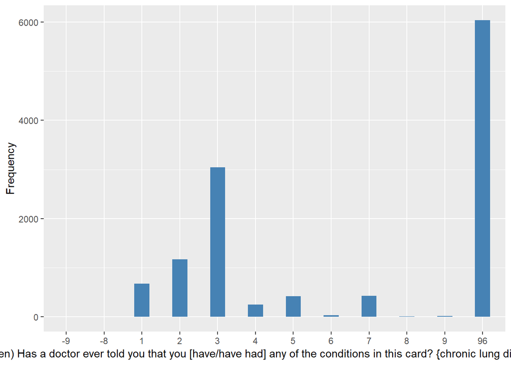

hedib02

| Sample size | Missing values |
| --- | --- |
| 12099 | 10312 |

Category

|  | 1 | 2 | 3 | 4 | 5 | 6 | 7 | 8 | 9 |
| --- | --- | --- | --- | --- | --- | --- | --- | --- | --- |
| Frequency | 72.0 | 239.00 | 641.0 | 237.00 | 231.00 | 18.00 | 319.00 | 2.00 | 28.00 |
| Percentage | 0.6 | 1.98 | 5.3 | 1.96 | 1.91 | 0.15 | 2.64 | 0.02 | 0.23 |

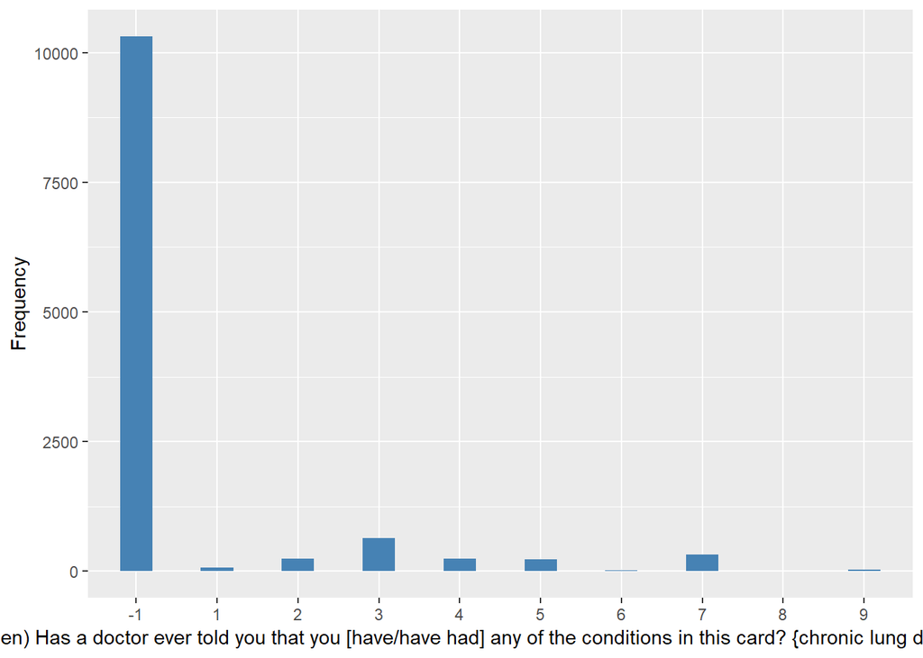

hedib03

| Sample size | Missing values |
| --- | --- |
| 12099 | 11687 |

Category

|  | 1 | 2 | 3 | 4 | 5 | 6 | 7 | 8 | 9 |
| --- | --- | --- | --- | --- | --- | --- | --- | --- | --- |
| Frequency | 10.00 | 4.00 | 126.00 | 70.00 | 62.00 | 4.00 | 122.00 | 2.00 | 12.0 |
| Percentage | 0.08 | 0.03 | 1.04 | 0.58 | 0.51 | 0.03 | 1.01 | 0.02 | 0.1 |

[figure not shown]

hedib04

| Sample size | Missing values |
| --- | --- |
| 12099 | 12028 |

Category

|  | 1 | 2 | 3 | 4 | 5 | 6 | 7 | 9 |
| --- | --- | --- | --- | --- | --- | --- | --- | --- |
| Frequency | 1.00 | 1.00 | 1.00 | 18.00 | 11.00 | 1.00 | 35.00 | 3.00 |
| Percentage | 0.01 | 0.01 | 0.01 | 0.15 | 0.09 | 0.01 | 0.29 | 0.02 |

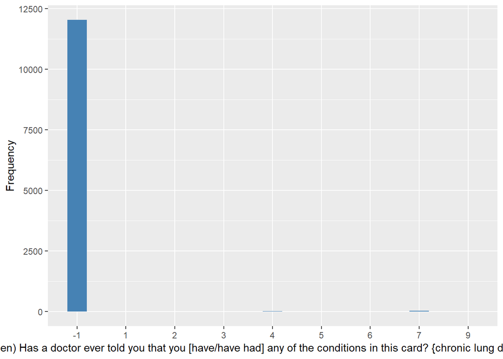

hedib05

| Sample size | Missing values |
| --- | --- |
| 12099 | 12089 |

Category

|  | 2 | 5 | 7 |
| --- | --- | --- | --- |
| Frequency | 1.00 | 2.00 | 7.00 |
| Percentage | 0.01 | 0.02 | 0.06 |

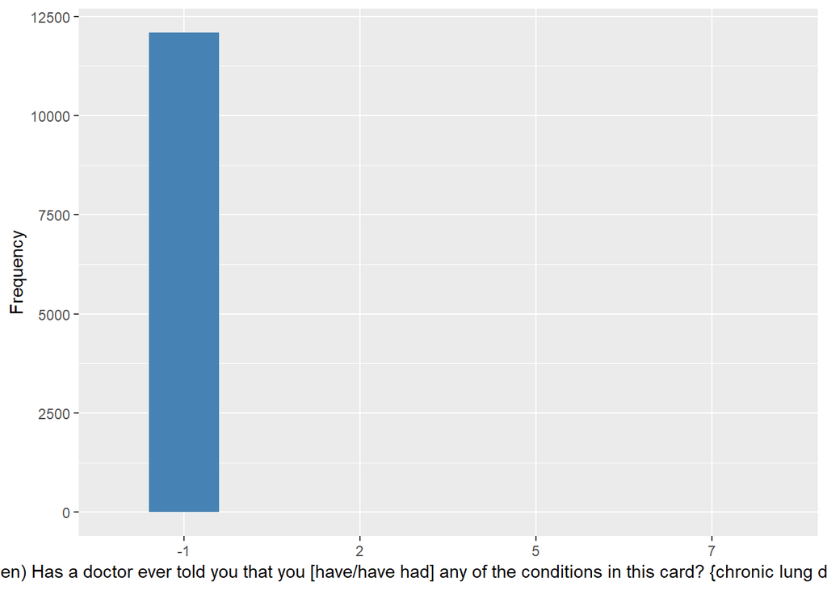

hedib06

| Sample size | Missing values |
| --- | --- |
| 12099 | 12098 |

Category

|  | 8 |
| --- | --- |
| Frequency | 1.00 |
| Percentage | 0.01 |

hedib07

| Sample size | Missing values |
| --- | --- |
| 12099 | 12099 |

Category

| Frequency |
| --- |
| Percentage |

hedib08

| Sample size | Missing values |
| --- | --- |
| 12099 | 12099 |

Category

| Frequency |
| --- |
| Percentage |

hedib09

| Sample size | Missing values |
| --- | --- |
| 12099 | 12099 |

Category

| Frequency |
| --- |
| Percentage |

hedib10

| Sample size | Missing values |
| --- | --- |
| 12099 | 12099 |

Category

| Frequency |
| --- |
| Percentage |

heagg

| Sample size | Missing values |
| --- | --- |
| 12099 | 11372 |

Summary

| Min. | 1st Qu. | Median | Mean | 3rd Qu. | Max. |
| --- | --- | --- | --- | --- | --- |
| 9 | 50 | 60 | 59.1 | 68.5 | 89 |

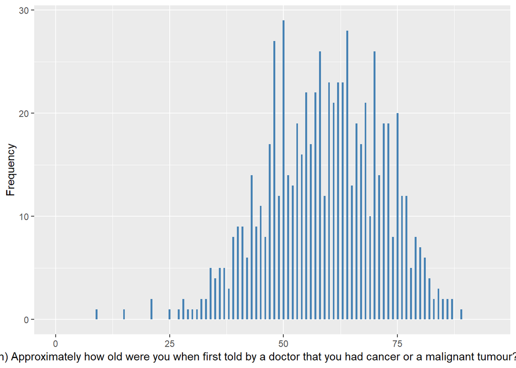

#### 2.1.1.2 Harmonisation algorithm

To compute `cancer` from the study-specific variable it has to be recoded as follows:

- `some hedibX == 5 into 1`
- `-9 into 997`
- `-8 into 998`
- `otherwise into 0`

To compute `cancer_age` from the study-specific variable it has to be recoded as follows:

- `if cancer == 1, cancer_age = heagg`
- `if cancer == 0, cancer_age = 996`
- `-9 into 997`
- `-8 into 998`
- `otherwise, cancer_age = 999`

**R script:**

```r
# Categorical variable harmonization
ELSA_ds_w1 <- tibble(id = ELSA_w1$id)
ELSA_ds_w1$cancer <- rep(0, length(ELSA_w1$id))
ELSA_ds_w1$cancer[which(ELSA_w1$hedib01 == 5 | ELSA_w1$hedib02 == 5 | ELSA_w1$hedib03 ==
    5 | ELSA_w1$hedib04 == 5 | ELSA_w1$hedib05 == 5 | ELSA_w1$hedib06 == 5 |
    ELSA_w1$hedib07 == 5 | ELSA_w1$hedib08 == 5 | ELSA_w1$hedib09 == 5 | ELSA_w1$hedib10 ==
    5)] <- 1
ELSA_ds_w1$cancer[which(ELSA_w1$hedib01 == -9)] <- 997
ELSA_ds_w1$cancer[which(ELSA_w1$hedib01 == -8)] <- 998

# Continuous variable harmonization
ELSA_ds_w1$cancer_age <- rep(999, length(ELSA_w1$id))
ELSA_ds_w1$cancer_age[which(ELSA_ds_w1$cancer == 0)] <- 996
ELSA_ds_w1$cancer_age[which(ELSA_ds_w1$cancer == 1)] <- car::recode(ELSA_w1$heagg[which(ELSA_ds_w1$cancer ==
    1)], "-1=996;-8=998;-9=997")
```

#### 2.1.1.3 Statistics of the new harmonized variable

Any malignancy (C00-D48) / information about past or current neoplasm (benign, in situ, malignant)

| Sample size | Missing values |
| --- | --- |
| 12099 | 10 |

Category

|  | 0 | 1 |
| --- | --- | --- |
| Frequency | 11362.00 | 727.00 |
| Percentage | 93.91 | 6.01 |

Type of missing

|  | 991 | 992 | 993 | 994 | 995 | 996 | 997 | 998 | 999 | NA |
| --- | --- | --- | --- | --- | --- | --- | --- | --- | --- | --- |
| Frequency | 0 | 0 | 0 | 0 | 0 | 0 | 4.00 | 6.00 | 0 | 0 |
| Percentage | 0 | 0 | 0 | 0 | 0 | 0 | 0.03 | 0.05 | 0 | 0 |

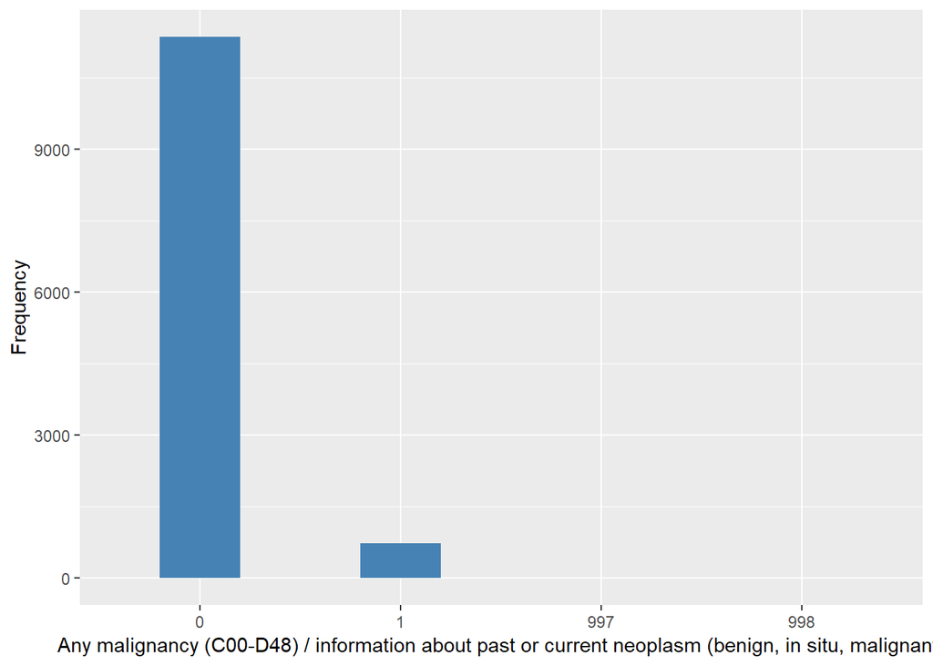

Age of the last cancer diagnosis

| Sample size | Missing values |
| --- | --- |
| 12099 | 11372 |

Values

|  | No-missings | 991 | 992 | 993 | 994 | 995 | 996 | 997 | 998 | 999 | NA |
| --- | --- | --- | --- | --- | --- | --- | --- | --- | --- | --- | --- |
| Frequency | 727.00 | 0 | 0 | 0 | 0 | 0 | 11362.00 | 0 | 0 | 10.00 | 0 |
| Percentage | 6.01 | 0 | 0 | 0 | 0 | 0 | 93.91 | 0 | 0 | 0.08 | 0 |

Summary

| Min. | 1st Qu. | Median | Mean | 3rd Qu. | Max. |
| --- | --- | --- | --- | --- | --- |
| 9 | 50 | 60 | 59.1 | 68.5 | 89 |

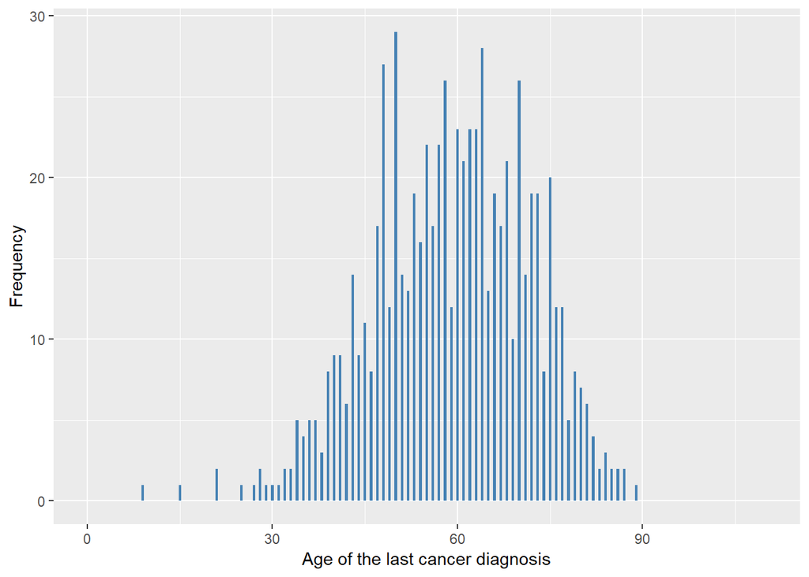

#### 2.1.1.4 Validation

|  | hedibX!=5->0 | hedibX==5->1 | hedibX==-9->997 | hedibX==-8->998 |
| --- | --- | --- | --- | --- |
| BeforeH | 11362 | 727 | 4 | 6 |
| AfterH | 11362 | 727 | 4 | 6 |

### 2.1.2 Wave 2

#### 2.1.2.1 Study-specific variable description

| **Name** | `hedib01` | `hedib02` | `hedib03` | `hedib04` | `HeAggRY` | `ybirth` |
| --- | --- | --- | --- | --- | --- | --- |
| **Label** | `Diagnosed chronic condition newly reported at W2 (1st mention)` | `Diagnosed chronic condition newly reported at W2 (2nd mention)` | `Diagnosed chronic condition newly reported at W2 (3rd mention)` | `Diagnosed chronic condition newly reported at W2 (4th mention)` | `Year told had cancer in last 2 years` | `year of birth` |
| **Table name** | `wave_2_core_data_v4` | `wave_2_core_data_v4` | `wave_2_core_data_v4` | `wave_2_core_data_v4` | `wave_2_core_data_v4` | `elsa_w2_hd` |
| **Categories** | `1 = Chronic lung disease such as chronic bronchitis or emphysema` `2 = Asthma` `3 = Arthritis (including osteoarthritis , or rheumatism)` `4 = Osteoporosis, sometimes called thin or brittle bones` `5… | `1 = Chronic lung disease such as chronic bronchitis or emphysema` `2 = Asthma` `3 = Arthritis (including osteoarthritis , or rheumatism)` `4 = Osteoporosis, sometimes called thin or brittle bones` `5… | `1 = Chronic lung disease such as chronic bronchitis or emphysema` `2 = Asthma` `3 = Arthritis (including osteoarthritis , or rheumatism)` `4 = Osteoporosis, sometimes called thin or brittle bones` `5… | `1 = Chronic lung disease such as chronic bronchitis or emphysema` `2 = Asthma` `3 = Arthritis (including osteoarthritis , or rheumatism)` `4 = Osteoporosis, sometimes called thin or brittle bones` `5… | `continuous` | `continuous` |
| **Missings** | `-9 = Refusal` `-8 = Don't know` `-1 = Not applicable` | `-9 = Refusal` `-8 = Don't know` `-1 = Not applicable` | `-9 = Refusal` `-8 = Don't know` `-1 = Not applicable` | `-9 = Refusal` `-8 = Don't know` `-1 = Not applicable` | `-9 = Refusal` `-8 = Don't know` `-1 = Not applicable` |  |
| **Description** |  |  |  |  |  |  |

hedib01

| Sample size | Missing values |
| --- | --- |
| 9432 | 6 |

Category

|  | 1 | 2 | 3 | 4 | 5 | 6 | 7 | 8 | 9 | 96 |
| --- | --- | --- | --- | --- | --- | --- | --- | --- | --- | --- |
| Frequency | 143.00 | 128.00 | 574.00 | 183.00 | 175.00 | 18.00 | 193.00 | 11.00 | 33.00 | 7968.00 |
| Percentage | 1.52 | 1.36 | 6.09 | 1.94 | 1.86 | 0.19 | 2.05 | 0.12 | 0.35 | 84.48 |

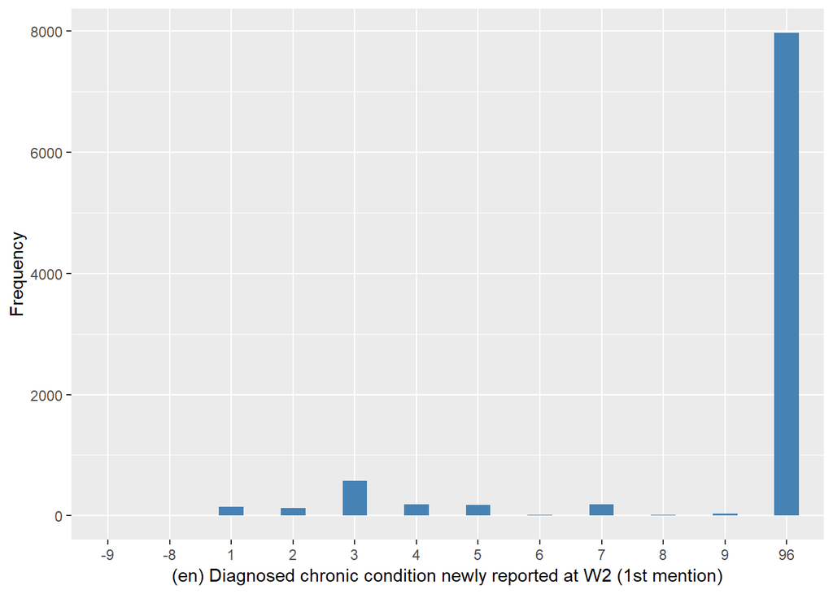

hedib02

| Sample size | Missing values |
| --- | --- |
| 9432 | 9310 |

Category

|  | 1 | 2 | 3 | 4 | 5 | 7 | 9 |
| --- | --- | --- | --- | --- | --- | --- | --- |
| Frequency | 4.00 | 11.00 | 19.0 | 19.0 | 27.00 | 35.00 | 7.00 |
| Percentage | 0.04 | 0.12 | 0.2 | 0.2 | 0.29 | 0.37 | 0.07 |

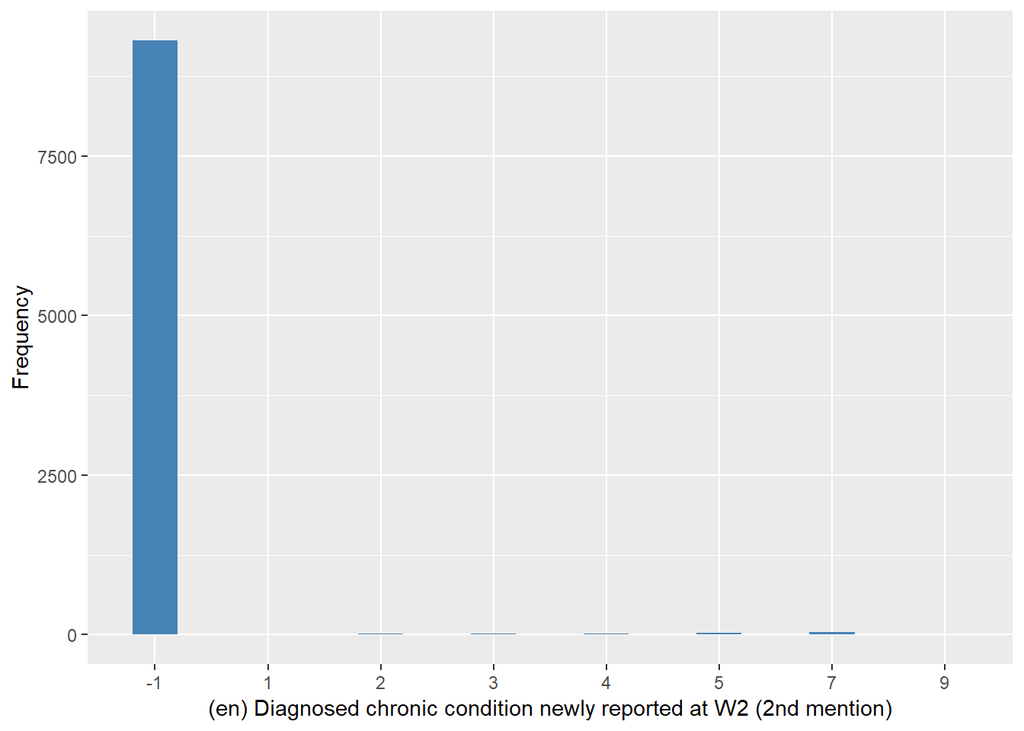

hedib03

| Sample size | Missing values |
| --- | --- |
| 9432 | 9419 |

Category

|  | 3 | 4 | 5 | 7 | 9 |
| --- | --- | --- | --- | --- | --- |
| Frequency | 3.00 | 2.00 | 2.00 | 3.00 | 3.00 |
| Percentage | 0.03 | 0.02 | 0.02 | 0.03 | 0.03 |

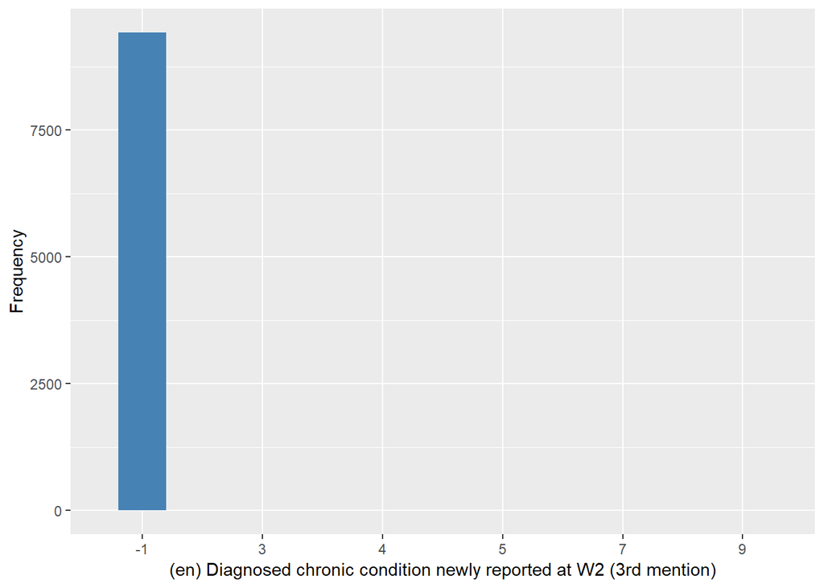

hedib04

| Sample size | Missing values |
| --- | --- |
| 9432 | 9428 |

Category

|  | 7 |
| --- | --- |
| Frequency | 4.00 |
| Percentage | 0.04 |

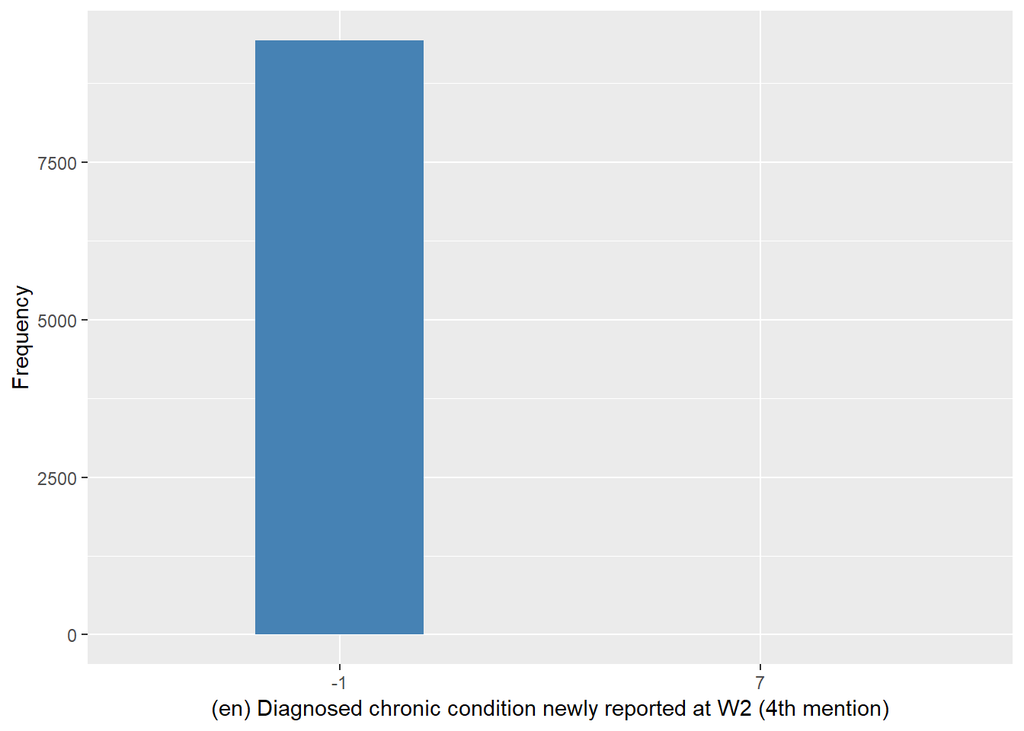

HeAggRY

| Sample size | Missing values |
| --- | --- |
| 9432 | 9258 |

Summary

| Min. | 1st Qu. | Median | Mean | 3rd Qu. | Max. |
| --- | --- | --- | --- | --- | --- |
| 1981 | 2003 | 2003 | 2003 | 2004 | 2005 |

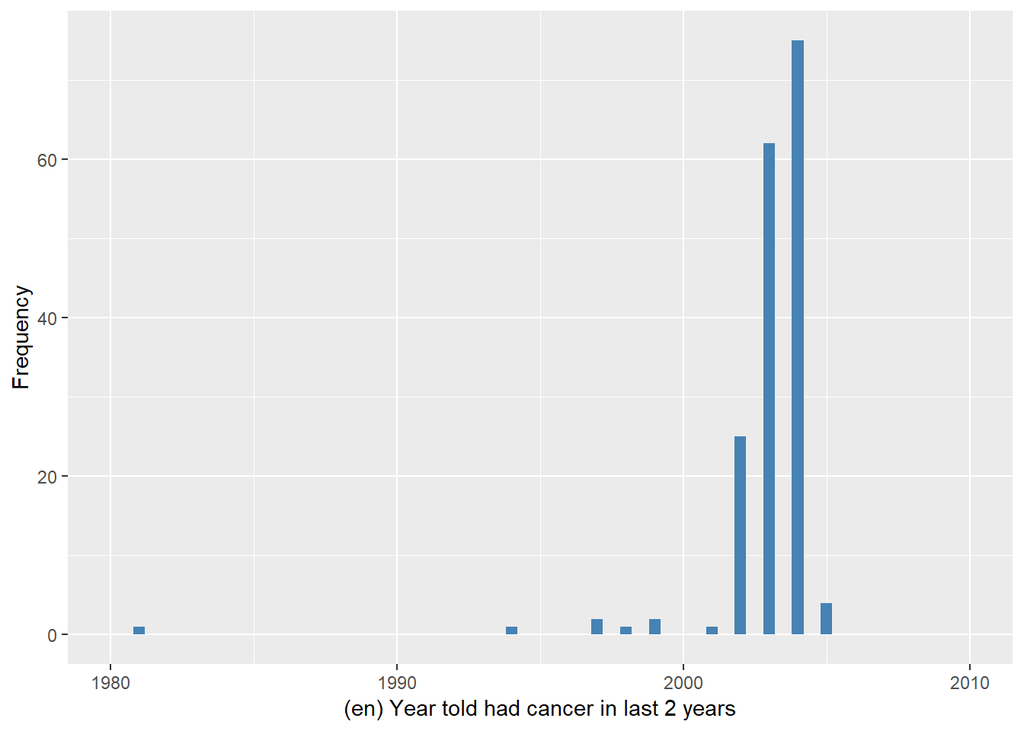

ybirth

| Sample size | Missing values |
| --- | --- |
| 9432 | 0 |

Summary

| Min. | 1st Qu. | Median | Mean | 3rd Qu. | Max. |
| --- | --- | --- | --- | --- | --- |
| 1908 | 1931 | 1939 | 1938 | 1947 | 1987 |

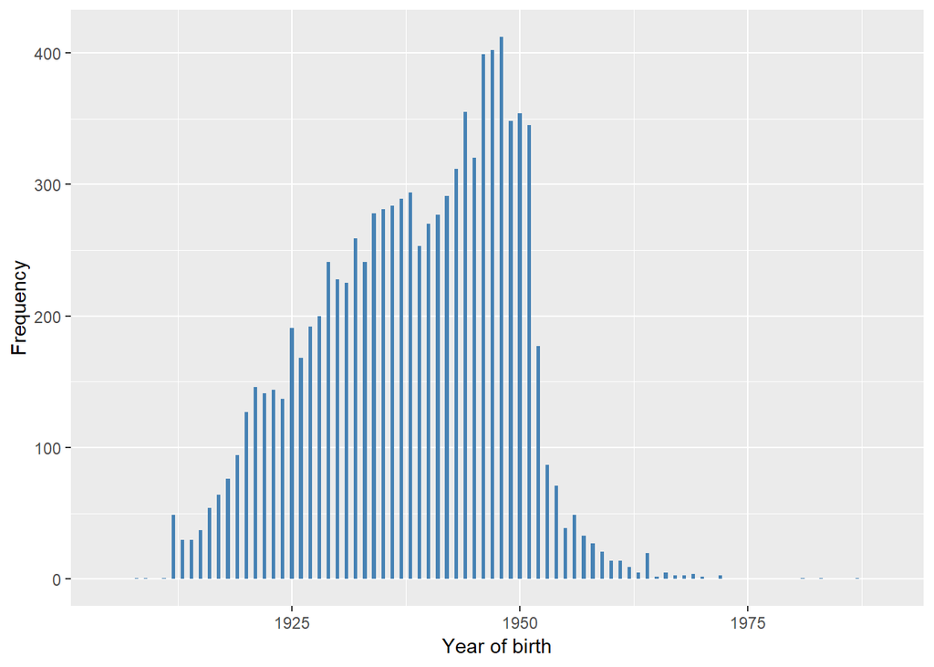

#### 2.1.2.2 Harmonisation algorithm

To compute `cancer` from the study-specific variable it has to be recoded as follows:

- `some hedibX == 5 into 1`
- `-9 into 997`
- `-8 into 998`
- `otherwise into 0`

To compute `cancer_age` from the study-specific variable it has to be recoded as follows:

- `if cancer == 1, cancer_age = HeAggRY-ybirth`
- `if cancer == 0, cancer_age = 996`
- `-9 into 997`
- `-8 into 998`
- `otherwise, cancer_age = 999`

**R script:**

```r
# Categorical variable harmonization
ELSA_ds_w2 <- tibble(id = ELSA_w2$id)
ELSA_ds_w2$cancer <- rep(0, length(ELSA_w2$id))
ELSA_ds_w2$cancer[which(ELSA_w2$hedib01 == 5 | ELSA_w2$hedib02 == 5 | ELSA_w2$hedib03 ==
    5 | ELSA_w2$hedib04 == 5)] <- 1
ELSA_ds_w2$cancer[which(ELSA_w2$hedib01 == -9)] <- 997
ELSA_ds_w2$cancer[which(ELSA_w2$hedib01 == -8)] <- 998

# Continuous variable harmonization
ELSA_ds_w2$cancer_age <- rep(999, length(ELSA_w2$id))
ELSA_ds_w2$cancer_age[which(ELSA_ds_w2$cancer == 0)] <- 996
ELSA_ds_w2$cancer_age[which(ELSA_ds_w2$cancer == 1 & !ELSA_w2$HeAggRY %in% c(-1,
    -8, -9))] <- ELSA_w2$HeAggRY[which(ELSA_ds_w2$cancer == 1 & !ELSA_w2$HeAggRY %in%
    c(-1, -8, -9))] - ELSA_w2$ybirth[which(ELSA_ds_w2$cancer == 1 & !ELSA_w2$HeAggRY %in%
    c(-1, -8, -9))]
ELSA_ds_w2$cancer_age <- car::recode(ELSA_ds_w2$cancer_age, "-1=996;-8=998;-9=997;NA=999")
```

#### 2.1.2.3 Statistics of the new harmonized variable

Any malignancy (C00-D48) / information about past or current neoplasm (benign, in situ, malignant)

| Sample size | Missing values |
| --- | --- |
| 9432 | 6 |

Category

|  | 0 | 1 |
| --- | --- | --- |
| Frequency | 9222.00 | 204.00 |
| Percentage | 97.77 | 2.16 |

Type of missing

|  | 991 | 992 | 993 | 994 | 995 | 996 | 997 | 998 | 999 | NA |
| --- | --- | --- | --- | --- | --- | --- | --- | --- | --- | --- |
| Frequency | 0 | 0 | 0 | 0 | 0 | 0 | 1.00 | 5.00 | 0 | 0 |
| Percentage | 0 | 0 | 0 | 0 | 0 | 0 | 0.01 | 0.05 | 0 | 0 |

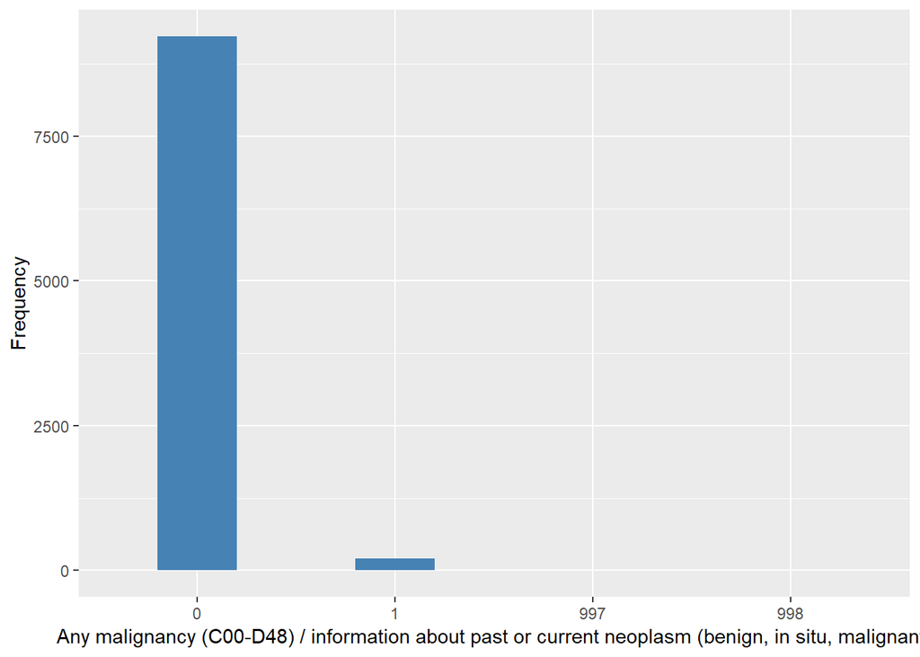

Age of the last cancer diagnosis

| Sample size | Missing values |
| --- | --- |
| 9432 | 9258 |

Values

|  | No-missings | 991 | 992 | 993 | 994 | 995 | 996 | 997 | 998 | 999 | NA |
| --- | --- | --- | --- | --- | --- | --- | --- | --- | --- | --- | --- |
| Frequency | 174.00 | 0 | 0 | 0 | 0 | 0 | 9222.00 | 0 | 0 | 36.00 | 0 |
| Percentage | 1.84 | 0 | 0 | 0 | 0 | 0 | 97.77 | 0 | 0 | 0.38 | 0 |

Summary

| Min. | 1st Qu. | Median | Mean | 3rd Qu. | Max. |
| --- | --- | --- | --- | --- | --- |
| 50 | 61 | 68 | 68.23 | 75 | 90 |

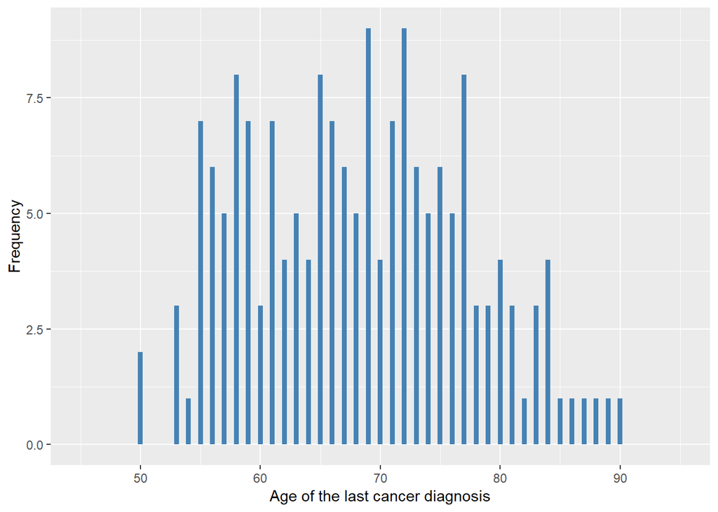

#### 2.1.2.4 Validation

|  | hedibX!=5->0 | hedibX==5->1 | hedibX==-9->997 | hedibX==-8->998 |
| --- | --- | --- | --- | --- |
| BeforeH | 9222 | 204 | 1 | 5 |
| AfterH | 9222 | 204 | 1 | 5 |

### 2.1.3 Wave 3

#### 2.1.3.1 Study-specific variable description

| **Name** | `dhedibca` | `ybirth` | `heaggry` |
| --- | --- | --- | --- |
| **Label** | `Chronic: cancer diagnosis newly reported` | `year of birth` | `Year told had cancer since last interview` |
| **Table name** | `wave_3_elsa_data_v4` | `elsa_w3_hd` | `wave_3_elsa_data_v4` |
| **Categories** | `1 = Mentioned` `0 = Not mentioned` | `continuous` | `continuous` |
| **Missings** | `-9 = Refusal` `-8 = Don't know` `-1 = Not applicable` | `998 = Do not know` | `-9 = Refusal` `-8 = Don't know` `-1 = Not applicable` |
| **Description** |  |  |  |

dhedibca

| Sample size | Missing values |
| --- | --- |
| 9771 | 9 |

Category

|  | 0 | 1 |
| --- | --- | --- |
| Frequency | 9529.00 | 233.00 |
| Percentage | 97.52 | 2.38 |

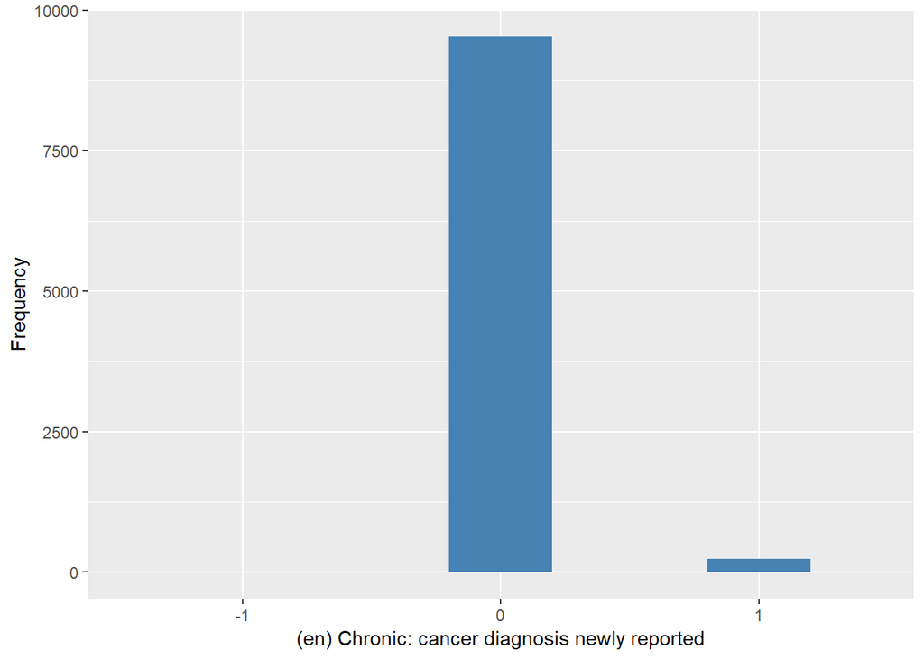

heaggry

| Sample size | Missing values |
| --- | --- |
| 9771 | 9604 |

Summary

| Min. | 1st Qu. | Median | Mean | 3rd Qu. | Max. |
| --- | --- | --- | --- | --- | --- |
| 1985 | 2004 | 2005 | 2004 | 2006 | 2006 |

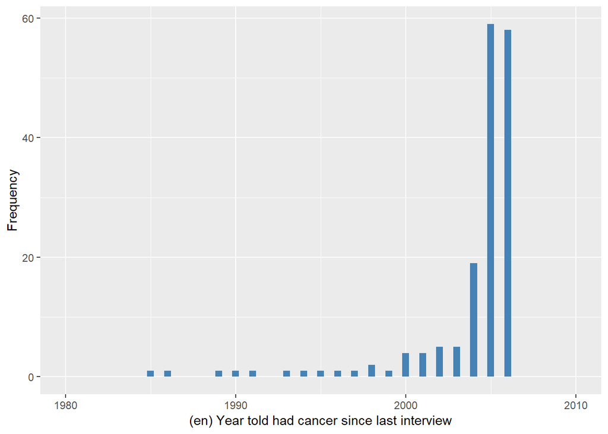

ybirth

| Sample size | Missing values |
| --- | --- |
| 9771 | 1 |

Summary

| Min. | 1st Qu. | Median | Mean | 3rd Qu. | Max. |
| --- | --- | --- | --- | --- | --- |
| 1908 | 1933 | 1943 | 1941 | 1950 | 1987 |

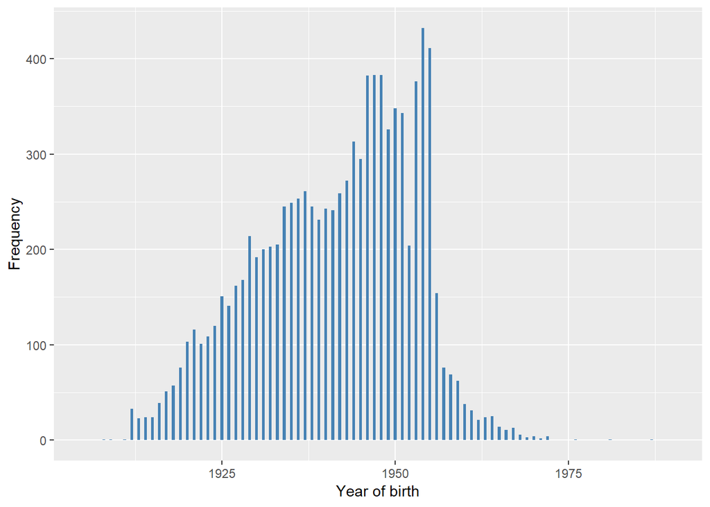

#### 2.1.3.2 Harmonisation algorithm

To compute `cancer` from the study-specific variable it has to be recoded as follows:

- `dhedibca == 1 into 1`
- `dhedibca == 0 into 0`
- `dhedibca == -1 into 996`

To compute `cancer_age` from the study-specific variable it has to be recoded as follows:

- `if cancer == 1, cancer_age = heaggry-ybirth`
- `if cancer == 0, cancer_age = 996`
- `-9 into 997`
- `-8 into 998`
- `otherwise, cancer_age = 999`

**R script:**

```r
# Categorical variable harmonization
ELSA_ds_w3 <- tibble(id = ELSA_w3$id)
ELSA_ds_w3$cancer <- car::recode(ELSA_w3$dhedibca, "-1=996")

# Continuous variable harmonization
ELSA_ds_w3$cancer_age <- rep(999, length(ELSA_w3$id))
ELSA_ds_w3$cancer_age[which(ELSA_ds_w3$cancer == 0)] <- 996
ELSA_ds_w3$cancer_age[which(ELSA_ds_w3$cancer == 1 & !ELSA_w3$heaggry %in% c(-1,
    -8, -9) & ELSA_w3$ybirth != 998)] <- ELSA_w3$heaggry[which(ELSA_ds_w3$cancer ==
    1 & !ELSA_w3$heaggry %in% c(-1, -8, -9) & ELSA_w3$ybirth != 998)] - ELSA_w3$ybirth[which(ELSA_ds_w3$cancer ==
    1 & !ELSA_w3$heaggry %in% c(-1, -8, -9) & ELSA_w3$ybirth != 998)]
ELSA_ds_w3$cancer_age <- car::recode(ELSA_ds_w3$cancer_age, "-1=996;-8=998;-9=997;NA=999")
```

#### 2.1.3.3 Statistics of the new harmonized variable

Any malignancy (C00-D48) / information about past or current neoplasm (benign, in situ, malignant)

| Sample size | Missing values |
| --- | --- |
| 9771 | 9 |

Category

|  | 0 | 1 |
| --- | --- | --- |
| Frequency | 9529.00 | 233.00 |
| Percentage | 97.52 | 2.38 |

Type of missing

|  | 991 | 992 | 993 | 994 | 995 | 996 | 997 | 998 | 999 | NA |
| --- | --- | --- | --- | --- | --- | --- | --- | --- | --- | --- |
| Frequency | 0 | 0 | 0 | 0 | 0 | 9.00 | 0 | 0 | 0 | 0 |
| Percentage | 0 | 0 | 0 | 0 | 0 | 0.09 | 0 | 0 | 0 | 0 |

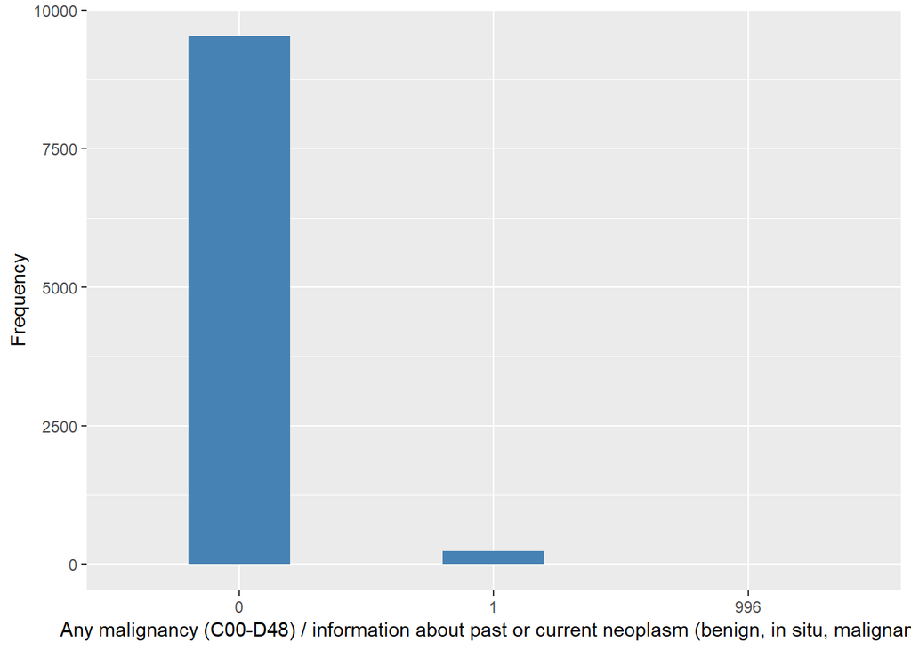

Age of the last cancer diagnosis

| Sample size | Missing values |
| --- | --- |
| 9771 | 9604 |

Values

|  | No-missings | 991 | 992 | 993 | 994 | 995 | 996 | 997 | 998 | 999 | NA |
| --- | --- | --- | --- | --- | --- | --- | --- | --- | --- | --- | --- |
| Frequency | 167.00 | 0 | 0 | 0 | 0 | 0 | 9529.00 | 0 | 0 | 75.00 | 0 |
| Percentage | 1.71 | 0 | 0 | 0 | 0 | 0 | 97.52 | 0 | 0 | 0.77 | 0 |

Summary

| Min. | 1st Qu. | Median | Mean | 3rd Qu. | Max. |
| --- | --- | --- | --- | --- | --- |
| 44 | 62 | 68 | 68.87 | 76 | 91 |

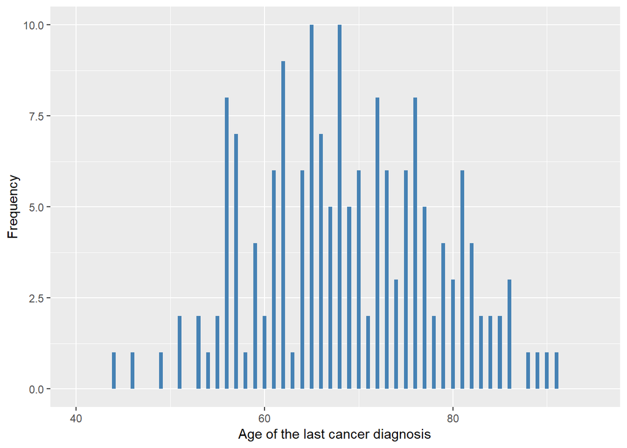

#### 2.1.3.4 Validation

|  | dhedibca==0->0 | dhedibca==1->1 | dhedibca==-1->996 |
| --- | --- | --- | --- |
| BeforeH | 9529 | 233 | 9 |
| AfterH | 9529 | 233 | 9 |

### 2.1.4 Wave 4

#### 2.1.4.1 Study-specific variable description

| **Name** | `hedibca` | `ybirth` | `heaggry` |
| --- | --- | --- | --- |
| **Label** | `Chronic: cancer diagnosis newly reported` | `year of birth` | `Year told had cancer since last interview` |
| **Table name** | `wave_4_elsa_data_v3` | `elsa_w4_hd` | `wave_4_elsa_data_v3` |
| **Categories** | `1 = Mentioned` `0 = Not mentioned` | `continuous` | `continuous` |
| **Missings** | `-9 = Refusal` `-8 = Don't know` `-1 = Not applicable` |  | `-9 = Refusal` `-8 = Don't know` `-2 = Capi/Interview Error` `-1 = Not applicable` |
| **Description** |  |  |  |

hedibca

| Sample size | Missing values |
| --- | --- |
| 11050 | 18 |

Category

|  | 0 | 1 |
| --- | --- | --- |
| Frequency | 10685.0 | 347.00 |
| Percentage | 96.7 | 3.14 |

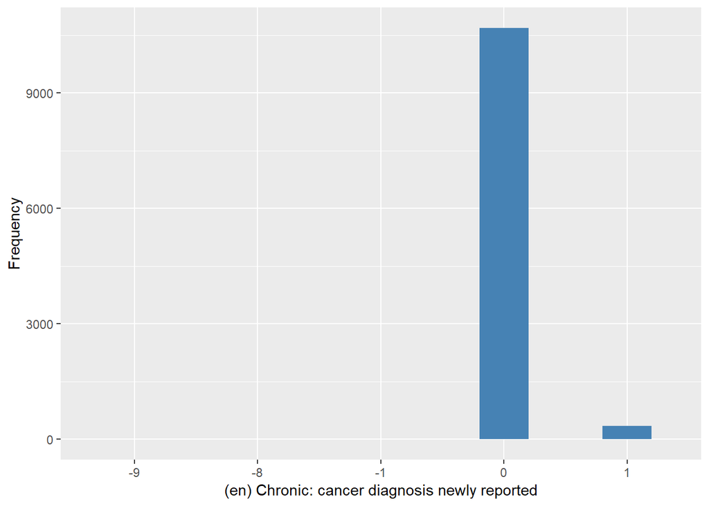

heaggry

| Sample size | Missing values |
| --- | --- |
| 11050 | 10873 |

Summary

| Min. | 1st Qu. | Median | Mean | 3rd Qu. | Max. |
| --- | --- | --- | --- | --- | --- |
| 1957 | 2006 | 2007 | 2005 | 2008 | 2009 |

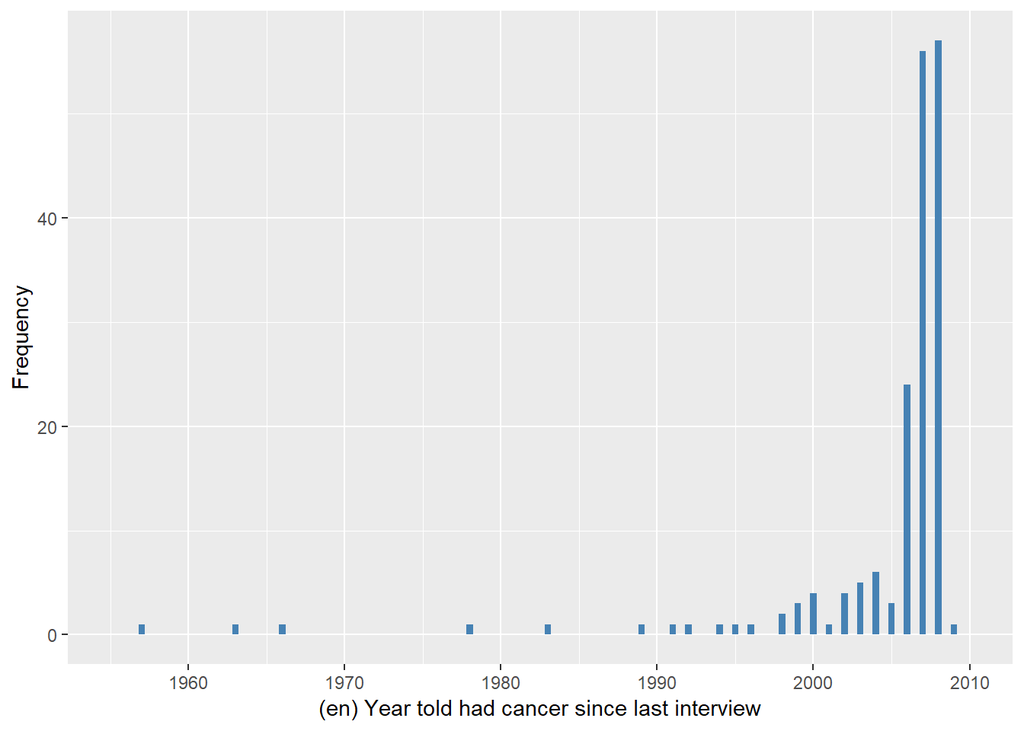

ybirth

| Sample size | Missing values |
| --- | --- |
| 11050 | 0 |

Summary

| Min. | 1st Qu. | Median | Mean | 3rd Qu. | Max. |
| --- | --- | --- | --- | --- | --- |
| 1908 | 1936 | 1944 | 1943 | 1951 | 1984 |

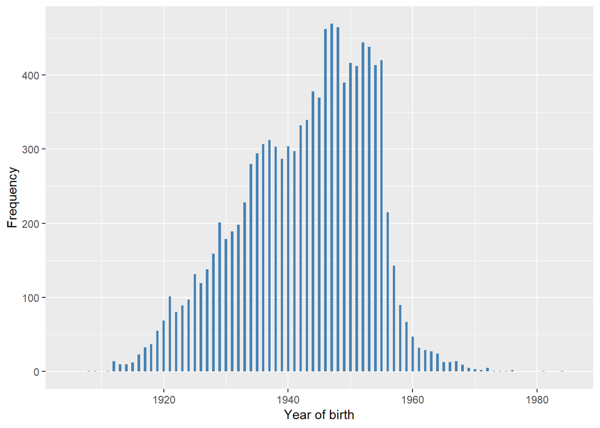

#### 2.1.4.2 Harmonisation algorithm

To compute `cancer` from the study-specific variable it has to be recoded as follows:

- `hedibca == 1 into 1`
- `hedibca == 0 into 0`
- `hedibca == -1 into 996`
- `hedibca == -9 into 997`
- `hedibca == -8 into 998`

To compute `cancer_age` from the study-specific variable it has to be recoded as follows:

- `if cancer == 1, cancer_age = heaggry-ybirth`
- `if cancer == 0, cancer_age = 996`
- `-9 into 997`
- `-8 into 998`
- `-2 into 991`
- `-1 into 996`
- `otherwise, cancer_age = 999`

**R script:**

```r
# Categorical variable harmonization
ELSA_ds_w4 <- tibble(id = ELSA_w4$id)
ELSA_ds_w4$cancer <- car::recode(ELSA_w4$hedibca, "-1=996;-8=998;-9=997")


# Continuous variable harmonization
ELSA_ds_w4$cancer_age <- rep(999, length(ELSA_w4$id))
ELSA_ds_w4$cancer_age[which(ELSA_ds_w4$cancer == 0)] <- 996
ELSA_ds_w4$cancer_age[which(ELSA_ds_w4$cancer == 1 & !ELSA_w4$heaggry %in% c(-1,
    -8, -9, -2))] <- ELSA_w4$heaggry[which(ELSA_ds_w4$cancer == 1 & !ELSA_w4$heaggry %in%
    c(-1, -8, -9, -2))] - ELSA_w4$ybirth[which(ELSA_ds_w4$cancer == 1 & !ELSA_w4$heaggry %in%
    c(-1, -8, -9, -2))]
ELSA_ds_w4$cancer_age <- car::recode(ELSA_ds_w4$cancer_age, "-1=996;-8=998;-9=997;-2=991;NA=999")
```

#### 2.1.4.3 Statistics of the new harmonized variable

Any malignancy (C00-D48) / information about past or current neoplasm (benign, in situ, malignant)

| Sample size | Missing values |
| --- | --- |
| 11050 | 18 |

Category

|  | 0 | 1 |
| --- | --- | --- |
| Frequency | 10685.0 | 347.00 |
| Percentage | 96.7 | 3.14 |

Type of missing

|  | 991 | 992 | 993 | 994 | 995 | 996 | 997 | 998 | 999 | NA |
| --- | --- | --- | --- | --- | --- | --- | --- | --- | --- | --- |
| Frequency | 0 | 0 | 0 | 0 | 0 | 3.00 | 5.00 | 10.00 | 0 | 0 |
| Percentage | 0 | 0 | 0 | 0 | 0 | 0.03 | 0.05 | 0.09 | 0 | 0 |

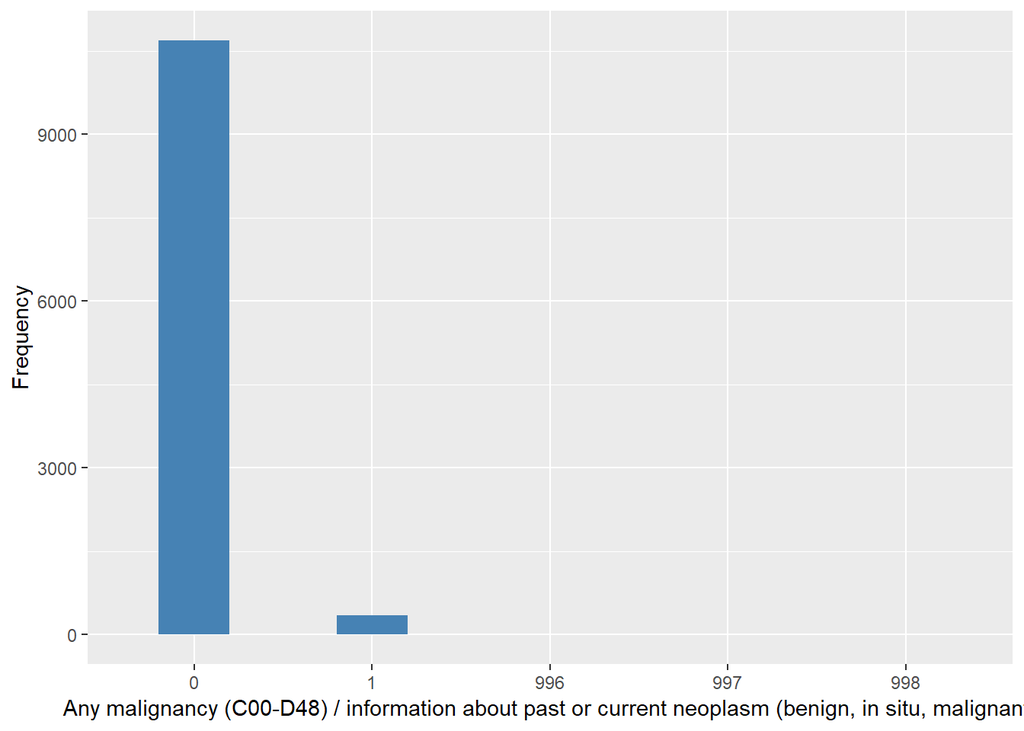

Age of the last cancer diagnosis

| Sample size | Missing values |
| --- | --- |
| 11050 | 10873 |

Values

|  | No-missings | 991 | 992 | 993 | 994 | 995 | 996 | 997 | 998 | 999 | NA |
| --- | --- | --- | --- | --- | --- | --- | --- | --- | --- | --- | --- |
| Frequency | 177.0 | 0 | 0 | 0 | 0 | 0 | 10685.0 | 0 | 0 | 188.0 | 0 |
| Percentage | 1.6 | 0 | 0 | 0 | 0 | 0 | 96.7 | 0 | 0 | 1.7 | 0 |

Summary

| Min. | 1st Qu. | Median | Mean | 3rd Qu. | Max. |
| --- | --- | --- | --- | --- | --- |
| 37 | 59 | 67 | 67.34 | 75 | 90 |

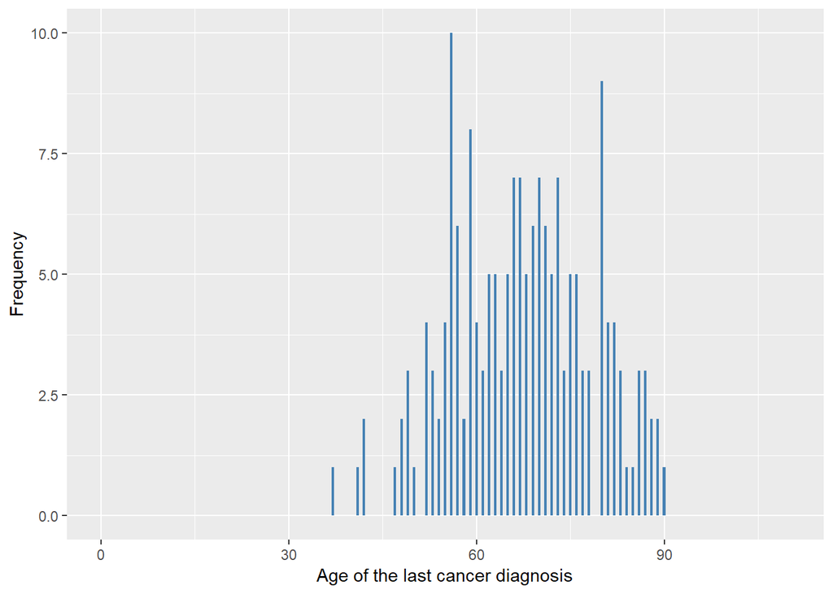

#### 2.1.4.4 Validation

|  | hedibca==0->0 | hedibca==1->1 | hedibca==-1->996 | hedibca==-9->997 | hedibca==-8->998 |
| --- | --- | --- | --- | --- | --- |
| BeforeH | 10685 | 347 | 3 | 5 | 10 |
| AfterH | 10685 | 347 | 3 | 5 | 10 |

### 2.1.5 Wave 5

#### 2.1.5.1 Study-specific variable description

| **Name** | `hedibca` | `ybirth` | `heaggry` |
| --- | --- | --- | --- |
| **Label** | `Chronic: cancer diagnosis newly reported` | `year of birth` | `Year told had cancer since last interview` |
| **Table name** | `wave_5_elsa_data_v4` | `elsa_w5_hd` | `wave_5_elsa_data_v4` |
| **Categories** | `1 = Mentioned` `0 = Not mentioned` | `continuous` | `continuous` |
| **Missings** | `-9 = Refusal` `-8 = Don't know` `-1 = Not applicable` |  | `-9 = Refusal` `-8 = Don't know` `-1 = Not applicable` |
| **Description** |  |  |  |

hedibca

| Sample size | Missing values |
| --- | --- |
| 10274 | 15 |

Category

|  | 0 | 1 |
| --- | --- | --- |
| Frequency | 9954.00 | 305.00 |
| Percentage | 96.89 | 2.97 |

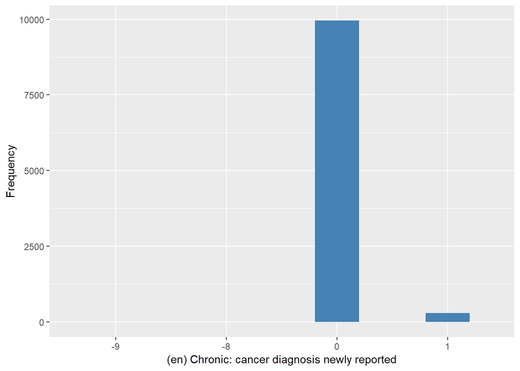

heaggry

| Sample size | Missing values |
| --- | --- |
| 10274 | 10004 |

Summary

| Min. | 1st Qu. | Median | Mean | 3rd Qu. | Max. |
| --- | --- | --- | --- | --- | --- |
| 1973 | 2008 | 2009 | 2007 | 2010 | 2011 |

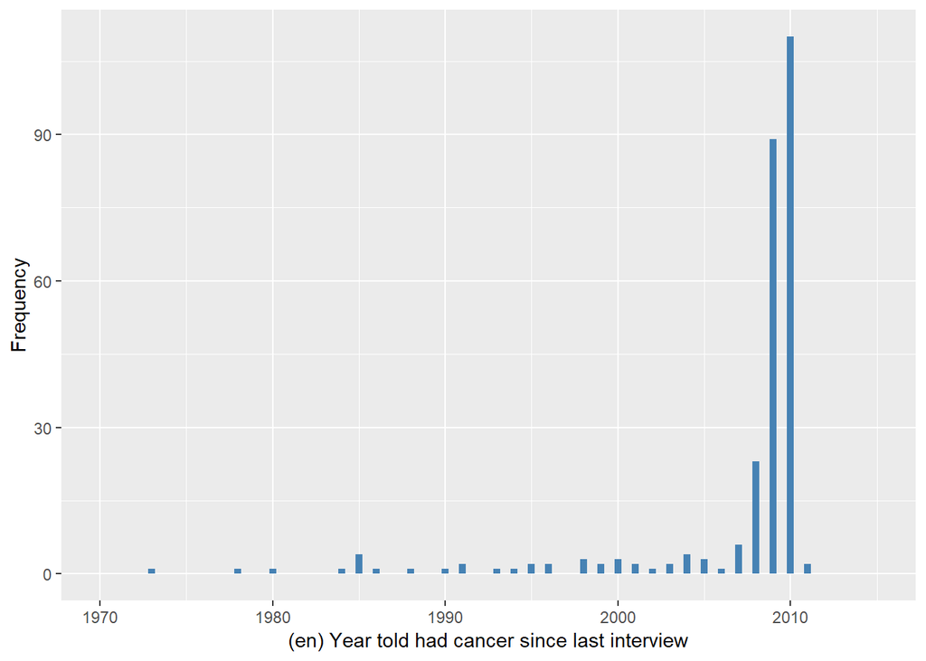

ybirth

| Sample size | Missing values |
| --- | --- |
| 10274 | 0 |

Summary

| Min. | 1st Qu. | Median | Mean | 3rd Qu. | Max. |
| --- | --- | --- | --- | --- | --- |
| 1908 | 1936 | 1945 | 1943 | 1951 | 1984 |

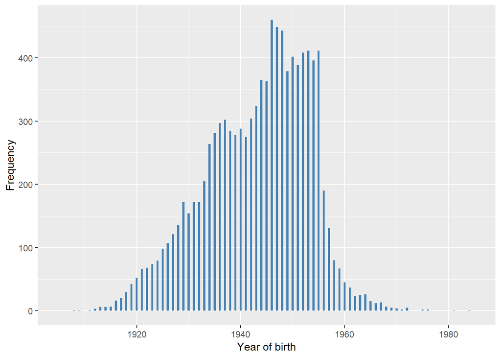

#### 2.1.5.2 Harmonisation algorithm

To compute `cancer` from the study-specific variable it has to be recoded as follows:

- `hedibca == 1 into 1`
- `hedibca == 0 into 0`
- `hedibca == -1 into 996`
- `hedibca == -9 into 997`
- `hedibca == -8 into 998`

To compute `cancer_age` from the study-specific variable it has to be recoded as follows:

- `if cancer == 1, cancer_age = heaggry-ybirth`
- `if cancer == 0, cancer_age = 996`
- `-9 into 997`
- `-8 into 998`
- `-1 into 996`
- `otherwise, cancer_age = 999`

**R script:**

```r
# Categorical variable harmonization
ELSA_ds_w5 <- tibble(id = ELSA_w5$id)
ELSA_ds_w5$cancer <- car::recode(ELSA_w5$hedibca, "-1=996;-8=998;-9=997")

# Continuous variable harmonization
ELSA_ds_w5$cancer_age <- rep(999, length(ELSA_w5$id))
ELSA_ds_w5$cancer_age[which(ELSA_ds_w5$cancer == 0)] <- 996
ELSA_ds_w5$cancer_age[which(ELSA_ds_w5$cancer == 1 & !ELSA_w5$heaggry %in% c(-1,
    -8, -9))] <- ELSA_w5$heaggry[which(ELSA_ds_w5$cancer == 1 & !ELSA_w5$heaggry %in%
    c(-1, -8, -9))] - ELSA_w5$ybirth[which(ELSA_ds_w5$cancer == 1 & !ELSA_w5$heaggry %in%
    c(-1, -8, -9))]
ELSA_ds_w5$cancer_age <- car::recode(ELSA_ds_w5$cancer_age, "-1=996;-8=998;-9=997;NA=999")
```

#### 2.1.5.3 Statistics of the new harmonized variable

Any malignancy (C00-D48) / information about past or current neoplasm (benign, in situ, malignant)

| Sample size | Missing values |
| --- | --- |
| 10274 | 15 |

Category

|  | 0 | 1 |
| --- | --- | --- |
| Frequency | 9954.00 | 305.00 |
| Percentage | 96.89 | 2.97 |

Type of missing

|  | 991 | 992 | 993 | 994 | 995 | 996 | 997 | 998 | 999 | NA |
| --- | --- | --- | --- | --- | --- | --- | --- | --- | --- | --- |
| Frequency | 0 | 0 | 0 | 0 | 0 | 0 | 4.00 | 11.00 | 0 | 0 |
| Percentage | 0 | 0 | 0 | 0 | 0 | 0 | 0.04 | 0.11 | 0 | 0 |

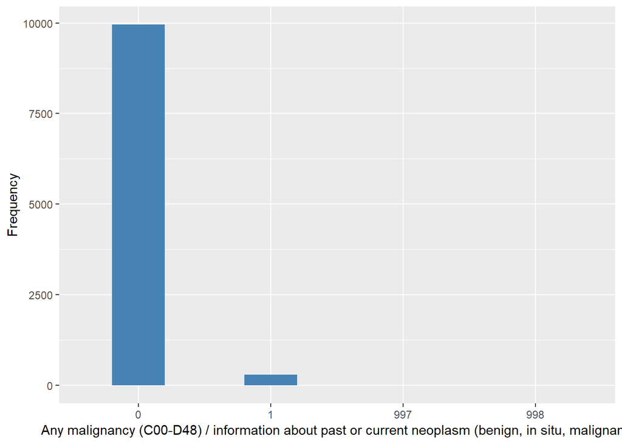

Age of the last cancer diagnosis

| Sample size | Missing values |
| --- | --- |
| 10274 | 10004 |

Values

|  | No-missings | 991 | 992 | 993 | 994 | 995 | 996 | 997 | 998 | 999 | NA |
| --- | --- | --- | --- | --- | --- | --- | --- | --- | --- | --- | --- |
| Frequency | 270.00 | 0 | 0 | 0 | 0 | 0 | 9954.00 | 0 | 0 | 50.00 | 0 |
| Percentage | 2.63 | 0 | 0 | 0 | 0 | 0 | 96.89 | 0 | 0 | 0.49 | 0 |

Summary

| Min. | 1st Qu. | Median | Mean | 3rd Qu. | Max. |
| --- | --- | --- | --- | --- | --- |
| 32 | 61 | 68 | 68.15 | 75 | 95 |

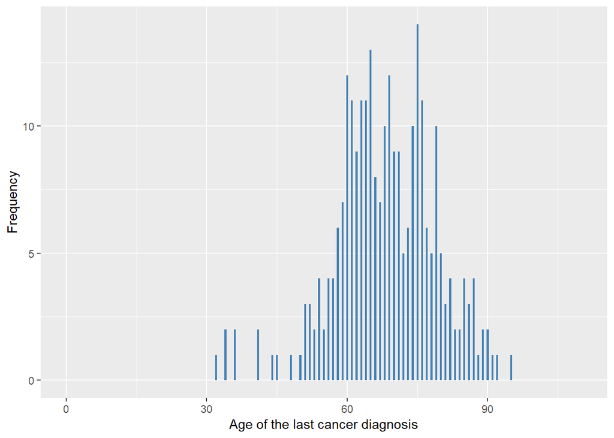

#### 2.1.5.4 Validation

|  | hedibca==0->0 | hedibca==1->1 | hedibca==-9->997 | hedibca==-8->998 |
| --- | --- | --- | --- | --- |
| BeforeH | 9954 | 305 | 4 | 11 |
| AfterH | 9954 | 305 | 4 | 11 |

### 2.1.6 Wave 6

#### 2.1.6.1 Study-specific variable description

| **Name** | `hedibca` | `ybirth` | `HeAggRY` |
| --- | --- | --- | --- |
| **Label** | `Chronic: cancer diagnosis newly reported` | `year of birth` | `Year told had cancer since last interview` |
| **Table name** | `wave_6_elsa_data_v2` | `elsa_w6_hd` | `wave_6_elsa_data_v2` |
| **Categories** | `1 = Mentioned` `0 = Not mentioned` | `continuous` | `continuous` |
| **Missings** | `-9 = Refusal` `-8 = Don't know` `-1 = Not applicable` |  | `-9 = Refusal` `-8 = Don't know` `-1 = Not applicable` |
| **Description** |  |  |  |

hedibca

| Sample size | Missing values |
| --- | --- |
| 10601 | 8 |

Category

|  | 0 | 1 |
| --- | --- | --- |
| Frequency | 10285.00 | 308.00 |
| Percentage | 97.02 | 2.91 |

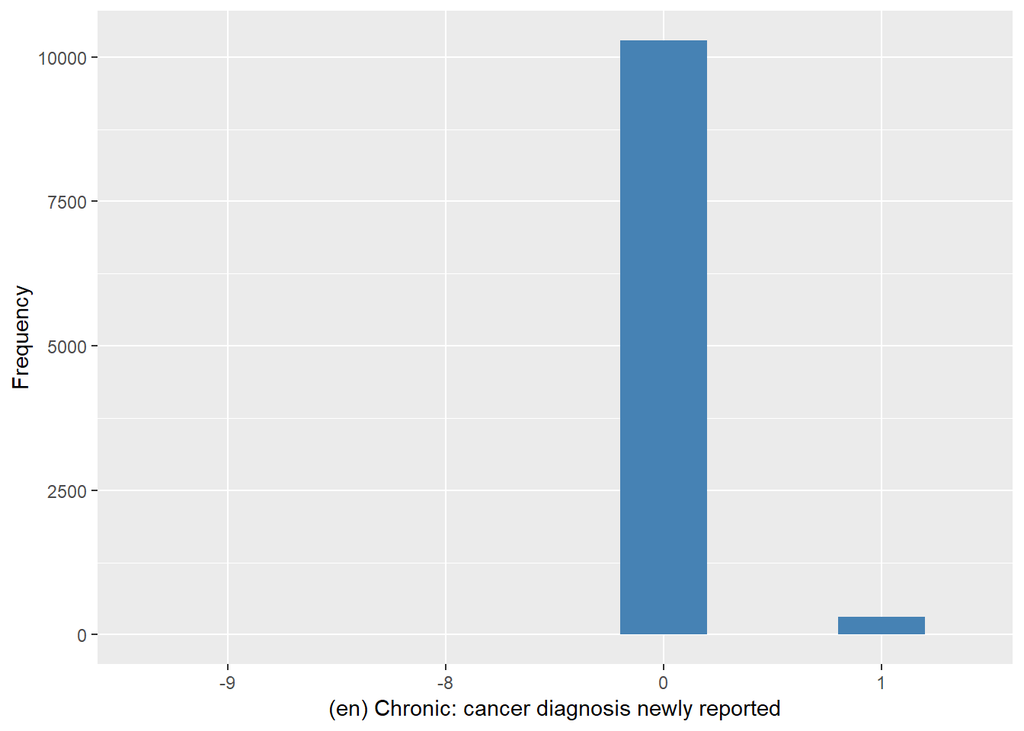

HeAggRY

| Sample size | Missing values |
| --- | --- |
| 10601 | 10389 |

Summary

| Min. | 1st Qu. | Median | Mean | 3rd Qu. | Max. |
| --- | --- | --- | --- | --- | --- |
| 1962 | 2010 | 2011 | 2009 | 2012 | 2012 |

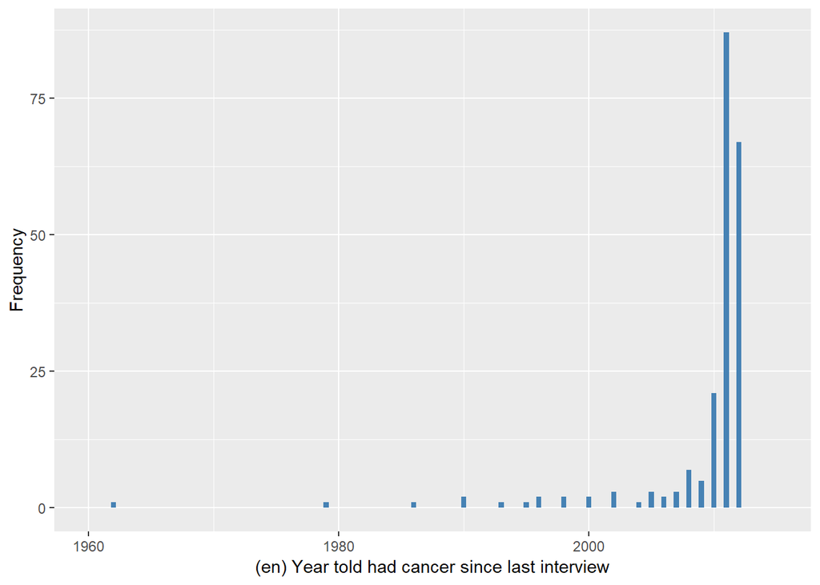

ybirth

| Sample size | Missing values |
| --- | --- |
| 10601 | 0 |

Summary

| Min. | 1st Qu. | Median | Mean | 3rd Qu. | Max. |
| --- | --- | --- | --- | --- | --- |
| 1911 | 1938 | 1946 | 1945 | 1953 | 1984 |

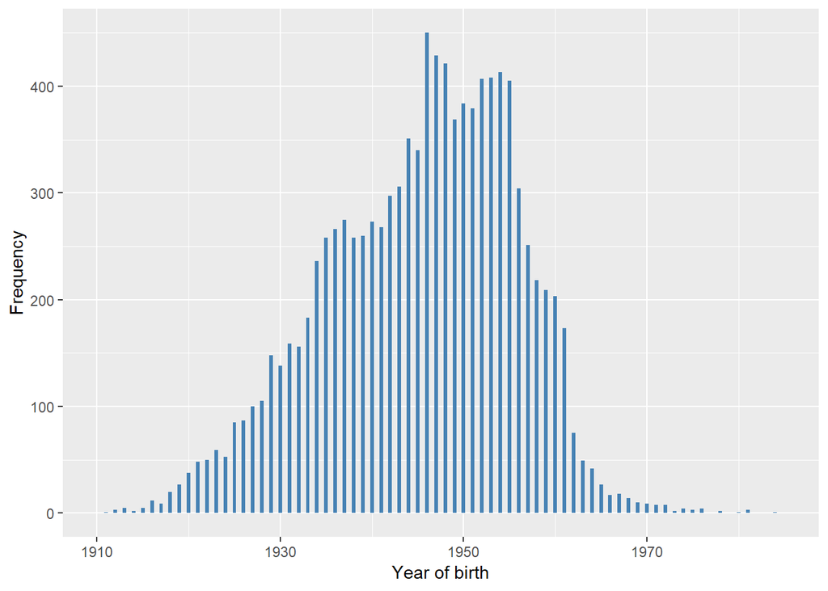

#### 2.1.6.2 Harmonisation algorithm

To compute `cancer` from the study-specific variable it has to be recoded as follows:

- `hedibca == 1 into 1`
- `hedibca == 0 into 0`
- `hedibca == -9 into 997`
- `hedibca == -8 into 998`

To compute `cancer_age` from the study-specific variable it has to be recoded as follows:

- `if cancer == 1, cancer_age = HeAggRY-ybirth`
- `if cancer == 0, cancer_age = 996`
- `-9 into 997`
- `-8 into 998`
- `-1 into 996`
- `otherwise, cancer_age = 999`

**R script:**

```r
# Categorical variable harmonization
ELSA_ds_w6 <- tibble(id = ELSA_w6$id)
ELSA_ds_w6$cancer <- car::recode(ELSA_w6$hedibca, "-1=996;-8=998;-9=997")

# Continuous variable harmonization
ELSA_ds_w6$cancer_age <- rep(999, length(ELSA_w6$id))
ELSA_ds_w6$cancer_age[which(ELSA_ds_w6$cancer == 0)] <- 996
ELSA_ds_w6$cancer_age[which(ELSA_ds_w6$cancer == 1 & !ELSA_w6$HeAggRY %in% c(-1,
    -8, -9))] <- ELSA_w6$HeAggRY[which(ELSA_ds_w6$cancer == 1 & !ELSA_w6$HeAggRY %in%
    c(-1, -8, -9))] - ELSA_w6$ybirth[which(ELSA_ds_w6$cancer == 1 & !ELSA_w6$HeAggRY %in%
    c(-1, -8, -9))]
ELSA_ds_w6$cancer_age <- car::recode(ELSA_ds_w6$cancer_age, "-1=996;-8=998;-9=997;NA=999")
```

#### 2.1.6.3 Statistics of the new harmonized variable

Any malignancy (C00-D48) / information about past or current neoplasm (benign, in situ, malignant)

| Sample size | Missing values |
| --- | --- |
| 10601 | 8 |

Category

|  | 0 | 1 |
| --- | --- | --- |
| Frequency | 10285.00 | 308.00 |
| Percentage | 97.02 | 2.91 |

Type of missing

|  | 991 | 992 | 993 | 994 | 995 | 996 | 997 | 998 | 999 | NA |
| --- | --- | --- | --- | --- | --- | --- | --- | --- | --- | --- |
| Frequency | 0 | 0 | 0 | 0 | 0 | 0 | 4.00 | 4.00 | 0 | 0 |
| Percentage | 0 | 0 | 0 | 0 | 0 | 0 | 0.04 | 0.04 | 0 | 0 |

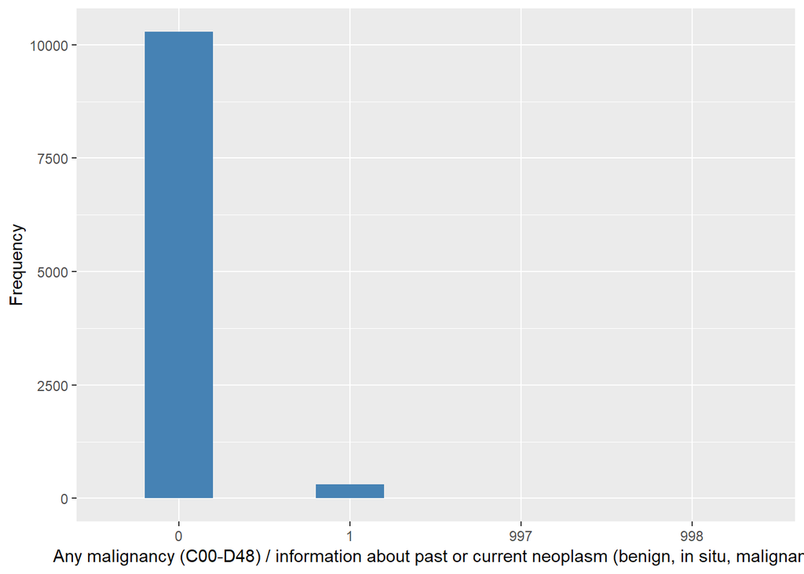

Age of the last cancer diagnosis

| Sample size | Missing values |
| --- | --- |
| 10601 | 10389 |

Values

|  | No-missings | 991 | 992 | 993 | 994 | 995 | 996 | 997 | 998 | 999 | NA |
| --- | --- | --- | --- | --- | --- | --- | --- | --- | --- | --- | --- |
| Frequency | 212 | 0 | 0 | 0 | 0 | 0 | 10285.00 | 0 | 0 | 104.00 | 0 |
| Percentage | 2 | 0 | 0 | 0 | 0 | 0 | 97.02 | 0 | 0 | 0.98 | 0 |

Summary

| Min. | 1st Qu. | Median | Mean | 3rd Qu. | Max. |
| --- | --- | --- | --- | --- | --- |
| 18 | 62 | 69 | 68.98 | 77 | 92 |

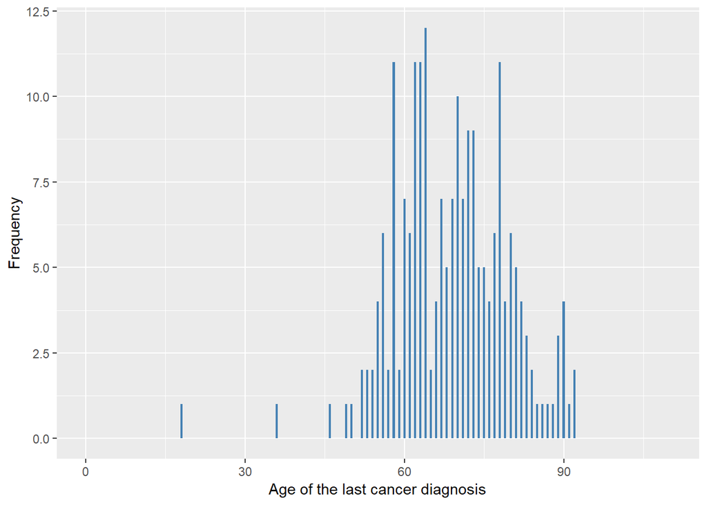

#### 2.1.6.4 Validation

|  | hedibca==0->0 | hedibca==1->1 | hedibca==-9->997 | hedibca==-8->998 |
| --- | --- | --- | --- | --- |
| BeforeH | 10285 | 308 | 4 | 4 |
| AfterH | 10285 | 308 | 4 | 4 |

### 2.1.7 Wave 7

#### 2.1.7.1 Study-specific variable description

| **Name** | `hedibca` | `ybirth` | `HeAggRY` |
| --- | --- | --- | --- |
| **Label** | `Chronic: cancer diagnosis newly reported` | `year of birth` | `Year told had cancer since last interview` |
| **Table name** | `wave_7_elsa_data` | `elsa_w7_hd` | `wave_7_elsa_data` |
| **Categories** | `1 = Mentioned` `0 = Not mentioned` | `continuous` | `continuous` |
| **Missings** | `-9 = Refusal` `-8 = Don't know` `-1 = Not applicable` |  | `-9 = Refusal` `-8 = Don't know` `-1 = Not applicable` |
| **Description** |  |  |  |

hedibca

| Sample size | Missing values |
| --- | --- |
| 9666 | 4 |

Category

|  | 0 | 1 |
| --- | --- | --- |
| Frequency | 9367.00 | 295.00 |
| Percentage | 96.91 | 3.05 |

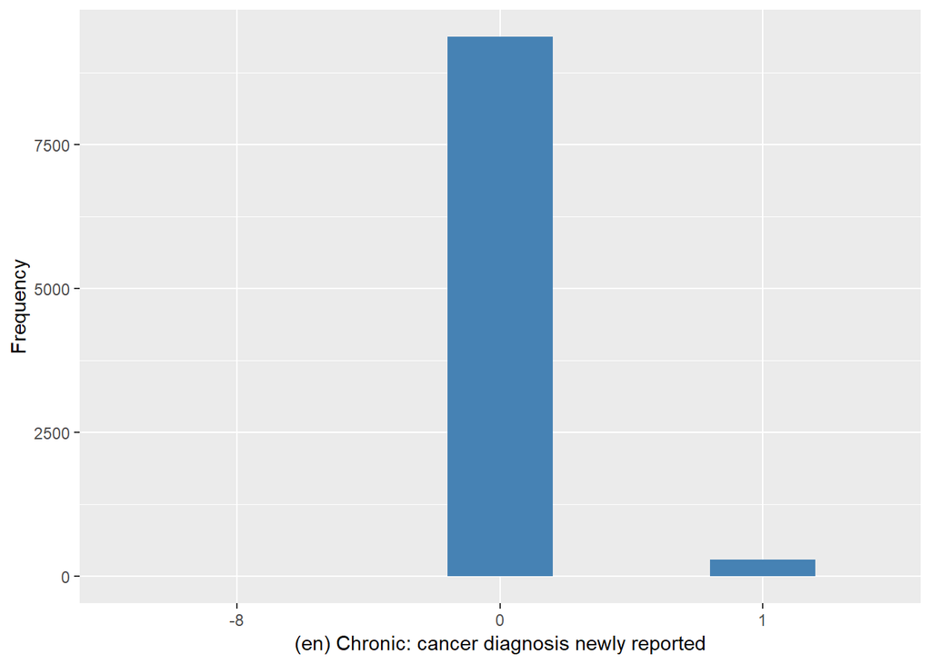

HeAggRY

| Sample size | Missing values |
| --- | --- |
| 9666 | 9423 |

Summary

| Min. | 1st Qu. | Median | Mean | 3rd Qu. | Max. |
| --- | --- | --- | --- | --- | --- |
| 1965 | 2012 | 2013 | 2012 | 2014 | 2015 |

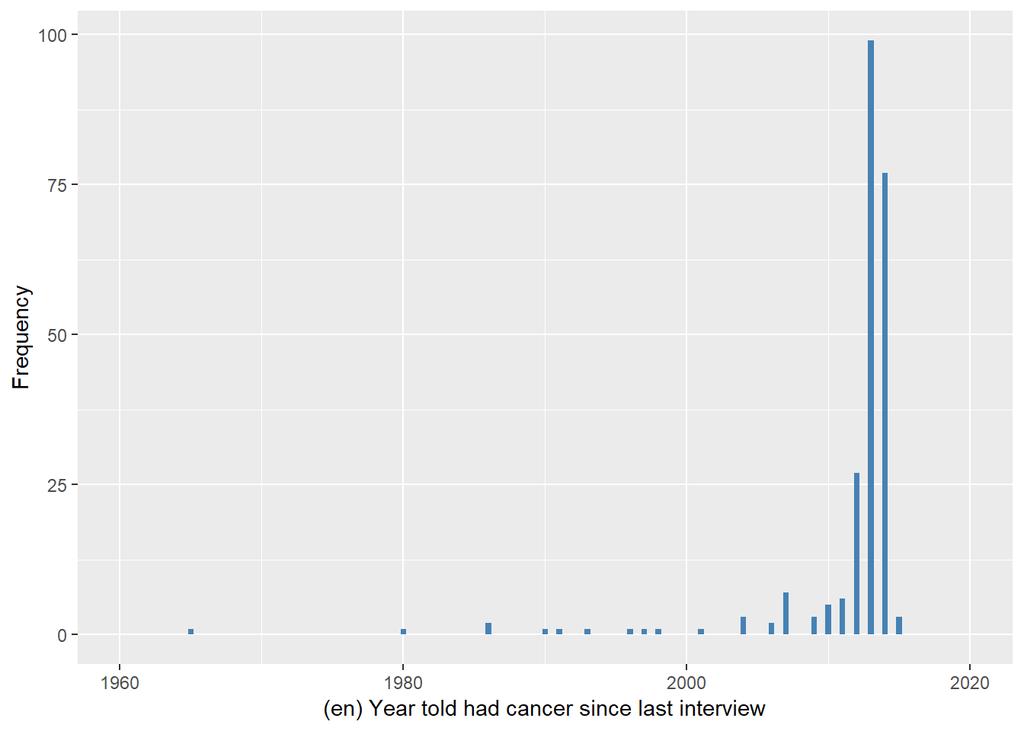

ybirth

| Sample size | Missing values |
| --- | --- |
| 9666 | 0 |

Summary

| Min. | 1st Qu. | Median | Mean | 3rd Qu. | Max. |
| --- | --- | --- | --- | --- | --- |
| 1911 | 1939 | 1947 | 1946 | 1954 | 1985 |

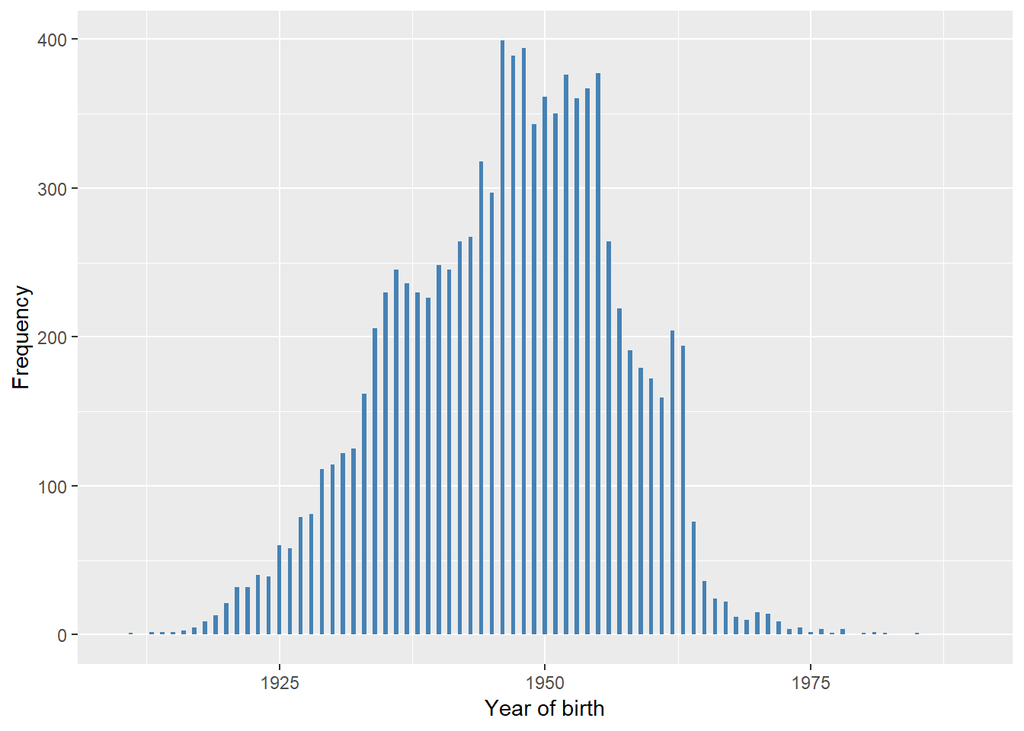

#### 2.1.7.2 Harmonisation algorithm

To compute `cancer` from the study-specific variable it has to be recoded as follows:

- `hedibca == 1 into 1`
- `hedibca == 0 into 0`
- `hedibca == -8 into 998`

To compute `cancer_age` from the study-specific variable it has to be recoded as follows:

- `if cancer == 1, cancer_age = HeAggRY-ybirth`
- `if cancer == 0, cancer_age = 996`
- `-9 into 997`
- `-8 into 998`
- `-1 into 996`
- `otherwise, cancer_age = 999`

**R script:**

```r
# Categorical variable harmonization
ELSA_ds_w7 <- tibble(id = ELSA_w7$id)
ELSA_ds_w7$cancer <- car::recode(ELSA_w7$hedibca, "-1=996;-8=998;-9=997")

# Continuous variable harmonization
ELSA_ds_w7$cancer_age <- rep(999, length(ELSA_w7$id))
ELSA_ds_w7$cancer_age[which(ELSA_ds_w7$cancer == 0)] <- 996
ELSA_ds_w7$cancer_age[which(ELSA_ds_w7$cancer == 1 & !ELSA_w7$HeAggRY %in% c(-1,
    -8, -9))] <- ELSA_w7$HeAggRY[which(ELSA_ds_w7$cancer == 1 & !ELSA_w7$HeAggRY %in%
    c(-1, -8, -9))] - ELSA_w7$ybirth[which(ELSA_ds_w7$cancer == 1 & !ELSA_w7$HeAggRY %in%
    c(-1, -8, -9))]
ELSA_ds_w7$cancer_age <- car::recode(ELSA_ds_w7$cancer_age, "-1=996;-8=998;-9=997;NA=999")
```

#### 2.1.7.3 Statistics of the new harmonized variable

Any malignancy (C00-D48) / information about past or current neoplasm (benign, in situ, malignant)

| Sample size | Missing values |
| --- | --- |
| 9666 | 4 |

Category

|  | 0 | 1 |
| --- | --- | --- |
| Frequency | 9367.00 | 295.00 |
| Percentage | 96.91 | 3.05 |

Type of missing

|  | 991 | 992 | 993 | 994 | 995 | 996 | 997 | 998 | 999 | NA |
| --- | --- | --- | --- | --- | --- | --- | --- | --- | --- | --- |
| Frequency | 0 | 0 | 0 | 0 | 0 | 0 | 0 | 4.00 | 0 | 0 |
| Percentage | 0 | 0 | 0 | 0 | 0 | 0 | 0 | 0.04 | 0 | 0 |

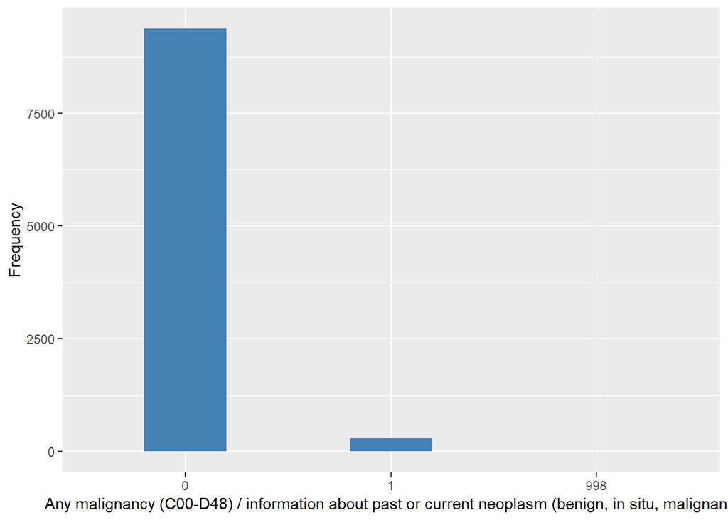

Age of the last cancer diagnosis

| Sample size | Missing values |
| --- | --- |
| 9666 | 9423 |

Values

|  | No-missings | 991 | 992 | 993 | 994 | 995 | 996 | 997 | 998 | 999 | NA |
| --- | --- | --- | --- | --- | --- | --- | --- | --- | --- | --- | --- |
| Frequency | 243.00 | 0 | 0 | 0 | 0 | 0 | 9367.00 | 0 | 0 | 56.00 | 0 |
| Percentage | 2.51 | 0 | 0 | 0 | 0 | 0 | 96.91 | 0 | 0 | 0.58 | 0 |

Summary

| Min. | 1st Qu. | Median | Mean | 3rd Qu. | Max. |
| --- | --- | --- | --- | --- | --- |
| 35 | 64 | 70 | 69.7 | 77 | 92 |

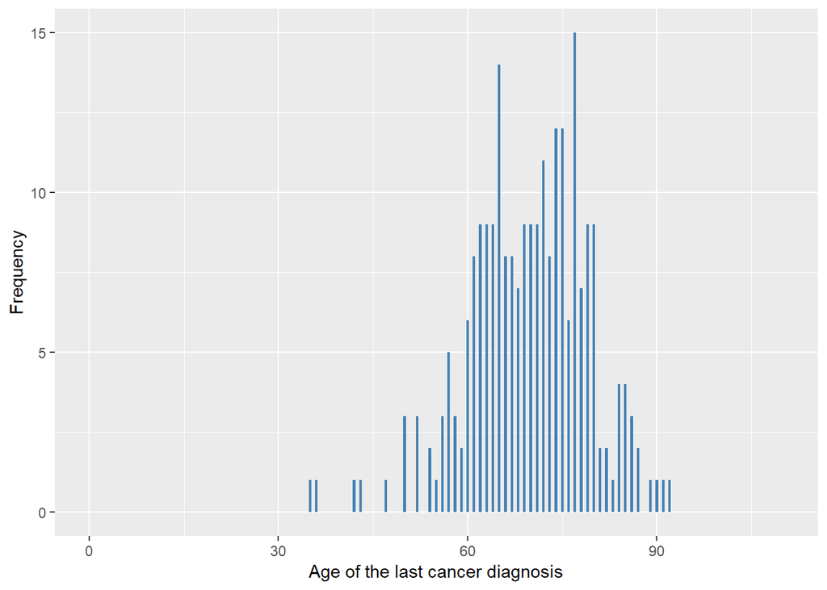

#### 2.1.7.4 Validation

|  | hedibca==0->0 | hedibca==1->1 | hedibca==-8->998 |
| --- | --- | --- | --- |
| BeforeH | 9367 | 295 | 4 |
| AfterH | 9367 | 295 | 4 |

## 2.2 Descriptive statistics of the harmonised variable `cancer` accross populations and waves

Two tables are generated:

1. Percentages of categories in each harmonised variable.
2. Frequencies and percentages of individuals with different trajectories. To avoid too large table, Only trajectories with percentages larger than 0.3 are shown.

Any malignancy (C00-D48) / information about past or current neoplasm (benign, in situ, malignant)

| val | label | W1 | W2 | W3 | W4 | W5 | W6 | W7 |
| --- | --- | --- | --- | --- | --- | --- | --- | --- |
| 0 | No | 93.91 | 97.77 | 97.52 | 96.7 | 96.89 | 97.02 | 96.91 |
| 1 | Yes | 6.01 | 2.16 | 2.38 | 3.14 | 2.97 | 2.91 | 3.05 |
| 991 | CAPI interviewer error | 0 | 0 | 0 | 0 | 0 | 0 | 0 |
| 992 | Impute | 0 | 0 | 0 | 0 | 0 | 0 | 0 |
| 993 | Disable to measure | 0 | 0 | 0 | 0 | 0 | 0 | 0 |
| 994 | Not attempt not done | 0 | 0 | 0 | 0 | 0 | 0 | 0 |
| 995 | Does not answer | 0 | 0 | 0 | 0 | 0 | 0 | 0 |
| 996 | Not applicable | 0 | 0 | 0.09 | 0.03 | 0 | 0 | 0 |
| 997 | Refuse | 0.03 | 0.01 | 0 | 0.05 | 0.04 | 0.04 | 0 |
| 998 | Do not know | 0.05 | 0.05 | 0 | 0.09 | 0.11 | 0.04 | 0.04 |
| 999 | Missing | 0 | 0 | 0 | 0 | 0 | 0 | 0 |
| NA | NA | 0 | 0 | 0 | 0 | 0 | 0 | 0 |
| n | sample size | 12099 | 9432 | 9771 | 11050 | 10274 | 10601 | 9666 |

|  | val | frq | raw.prc |
| --- | --- | --- | --- |
| 1 | 0000000 | 3710 | 20.07 |
| 2 | 0000001 | 113 | 0.61 |
| 3 | 000000NA | 576 | 3.12 |
| 4 | 0000010 | 72 | 0.39 |
| 6 | 00000NA0 | 57 | 0.31 |
| 8 | 00000NANA | 405 | 2.19 |
| 9 | 0000100 | 83 | 0.45 |
| 14 | 0000NA00 | 61 | 0.33 |
| 19 | 0000NANANA | 535 | 2.89 |
| 32 | 000NA000 | 105 | 0.57 |
| 50 | 000NANANANA | 821 | 4.44 |
| 64 | 00NA0000 | 99 | 0.54 |
| 98 | 00NANANANANA | 1152 | 6.23 |
| 123 | 0NA00000 | 94 | 0.51 |
| 147 | 0NA0NANANANA | 104 | 0.56 |
| 154 | 0NANA0000 | 60 | 0.32 |
| 185 | 0NANANANANANA | 1911 | 10.34 |
| 186 | 1000000 | 128 | 0.69 |
| 248 | 10NANANANANA | 92 | 0.50 |
| 287 | 1NANANANANANA | 170 | 0.92 |
| 314 | NANA00000 | 800 | 4.33 |
| 316 | NANA0000NA | 110 | 0.59 |
| 320 | NANA000NANA | 83 | 0.45 |
| 329 | NANA00NANANA | 115 | 0.62 |
| 333 | NANA0NA000 | 57 | 0.31 |
| 342 | NANA0NANANANA | 295 | 1.60 |
| 358 | NANANA0000 | 1512 | 8.18 |
| 360 | NANANA000NA | 242 | 1.31 |
| 366 | NANANA00NANA | 166 | 0.90 |
| 380 | NANANA0NANANA | 333 | 1.80 |
| 381 | NANANA1000 | 82 | 0.44 |
| 394 | NANANANA000 | 78 | 0.42 |
| 404 | NANANANANA00 | 891 | 4.82 |
| 406 | NANANANANA0NA | 248 | 1.34 |
| 410 | NANANANANANA0 | 484 | 2.62 |

## 2.3 Summary of descriptive statistics of the harmonised variable `cancer_age` accross populations and waves

Age of the last cancer diagnosis

| cancer_age | W1 | W2 | W3 | W4 | W5 | W6 | W7 |
| --- | --- | --- | --- | --- | --- | --- | --- |
| Min. | 9 | 50 | 44 | 37 | 32 | 18 | 35 |
| 1st Qu. | 50 | 61 | 62 | 59 | 61 | 62 | 64 |
| Median | 60 | 68 | 68 | 67 | 68 | 69 | 70 |
| Mean | 59.1 | 68.23 | 68.87 | 67.34 | 68.15 | 68.98 | 69.7 |
| 3rd Qu. | 68.5 | 75 | 76 | 75 | 75 | 77 | 77 |
| Max. | 89 | 90 | 91 | 90 | 95 | 92 | 92 |
| No-missings | 727 | 174 | 167 | 177 | 270 | 212 | 243 |
| 991 | 0 | 0 | 0 | 0 | 0 | 0 | 0 |
| 992 | 0 | 0 | 0 | 0 | 0 | 0 | 0 |
| 993 | 0 | 0 | 0 | 0 | 0 | 0 | 0 |
| 994 | 0 | 0 | 0 | 0 | 0 | 0 | 0 |
| 995 | 0 | 0 | 0 | 0 | 0 | 0 | 0 |
| 996 | 11362 | 9222 | 9529 | 10685 | 9954 | 10285 | 9367 |
| 997 | 0 | 0 | 0 | 0 | 0 | 0 | 0 |
| 998 | 0 | 0 | 0 | 0 | 0 | 0 | 0 |
| 999 | 10 | 36 | 75 | 188 | 50 | 104 | 56 |
| NA | 0 | 0 | 0 | 0 | 0 | 0 | 0 |
| sample size | 12099 | 9432 | 9771 | 11050 | 10274 | 10601 | 9666 |

# 3 Quality estimation

No comments